# MAT3373: Long Homework #2

Charie Brady (300043672)

10/04/2021

### Question 1

**Load the mnist.csv dataset. This is exactly the training dataset that you used in HW1, where you fit several knn models to this dataset and found a “best” value of k. In this problem, you will estimate the error of this procedure using cross-validation:**

```r
mnist_data = read.csv("mnist.csv")
```

**(1) Do 3-fold cross-validation, using this single value of k for the knn model. Report the estimated error.**

```r
set.seed(123)

train_control <- trainControl(method = "cv", number = 3)

knn_model <- train(label ~., data = mnist_data, tuneGrid = data.frame(k=3),
               method = "knn", trControl = train_control)
knn_model
```

```
## k-Nearest Neighbors
##
## 10000 samples
##   784 predictor
##
## No pre-processing
## Resampling: Cross-Validated (3 fold)
## Summary of sample sizes: 6667, 6667, 6666
## Resampling results:
##
##   RMSE       Rsquared  MAE
##   0.8711955  0.909965  0.2555667
##
## Tuning parameter 'k' was held constant at a value of 3
```

The 3-fold CV error: $RMSE = 0.87$

**(2) Open HW1, where you trained on the same dataset and found the test error. How do these results compare? How would you expect them to compare in general?**

The estimated error through 3-fold cross-validation is relatively low. This is expected when compared with a validation-set approach for two reasons.

First, the KNN classifier is trained over the entire data set through cross-validation, and generally models that are trained on more data perform better and have lower errors. Since the validation-set approach used in HW1 trained the model on less data, the error is expected to be an overestimate of the true error.

Second, the validation-set approach to estimating the error suffers from higher variability given that its estimate can change depending on where the data is split and which data points are included in the train and test sets. Since 3-fold cross-validation takes an average of three error estimates, the estimate will be less variable and closer to the true error.

Overall, it is expected that the estimated error is smaller using n-fold CV compared to the validation-set approach used in HW1.

### Question 2

**Download the red wine dataset from: https://archive.ics.uci.edu/ml/datasets/wine+quality. Your goal in this question is to predict wine quality based on all other variables.**

```r
set.seed(50)

wine_data = read.csv("winedata_split.csv")
head(wine_data)
```

```
##   fixed.acidity volatile.acidity citric.acid residual.sugar chlorides
## 1           7.4             0.70        0.00            1.9     0.076
## 2           7.8             0.88        0.00            2.6     0.098
## 3           7.8             0.76        0.04            2.3     0.092
## 4          11.2             0.28        0.56            1.9     0.075
## 5           7.4             0.70        0.00            1.9     0.076
## 6           7.4             0.66        0.00            1.8     0.075
##   free.sulfur.dioxide total.sulfur.dioxide density   pH sulphates alcohol
## 1                  11                   34  0.9978 3.51      0.56     9.4
## 2                  25                   67  0.9968 3.20      0.68     9.8
## 3                  15                   54  0.9970 3.26      0.65     9.8
## 4                  17                   60  0.9980 3.16      0.58     9.8
## 5                  11                   34  0.9978 3.51      0.56     9.4
## 6                  13                   40  0.9978 3.51      0.56     9.4
##   quality
## 1       5
## 2       5
## 3       5
## 4       6
## 5       5
## 6       5
```

Quick view of the columns, and check of the wine data set row count.

```r
nrow(wine_data)
```

```
## [1] 1599
```

**(1) Split the data set into a training set and a test set.**

```r
set.seed(100)

index <- createDataPartition(wine_data$quality, p = .5,
                                  list = FALSE,
                                  times = 1)
wine_data_train <- wine_data[index,]
wine_data_test <- wine_data[-index,]

nrow(wine_data_train)
```

```
## [1] 800
```

```r
nrow(wine_data_test)
```

```
## [1] 799
```

**(2) For each of the following, fit the given model, report any hyperparameters chosen, and report the test error.**

**(a) Fit a linear model using least squares.**

```r
linear_fit = lm(quality~., data=wine_data_train)

summary(linear_fit)
```

```
##
## Call:
## lm(formula = quality ~ ., data = wine_data_train)
##
## Residuals:
##      Min       1Q   Median       3Q      Max
## -2.67744 -0.36198 -0.06867  0.40868  1.88176
##
## Coefficients:
##                        Estimate Std. Error t value Pr(>|t|)
## (Intercept)           4.734e+01  2.972e+01   1.593  0.11155
## fixed.acidity         6.833e-02  3.697e-02   1.849  0.06490 .
## volatile.acidity     -1.309e+00  1.737e-01  -7.533 1.36e-13 ***
## citric.acid          -4.151e-01  2.115e-01  -1.963  0.04997 *
## residual.sugar        3.933e-02  1.868e-02   2.106  0.03553 *
## chlorides            -1.575e+00  5.649e-01  -2.787  0.00544 **
## free.sulfur.dioxide   7.399e-04  3.176e-03   0.233  0.81585
## total.sulfur.dioxide -1.609e-03  1.055e-03  -1.526  0.12750
## density              -4.482e+01  3.034e+01  -1.477  0.14003
## pH                   -6.667e-02  2.749e-01  -0.243  0.80843
## sulphates             8.453e-01  1.539e-01   5.494 5.31e-08 ***
## alcohol               2.865e-01  3.737e-02   7.665 5.24e-14 ***
## ---
## Signif. codes:  0 '***' 0.001 '**' 0.01 '*' 0.05 '.' 0.1 ' ' 1
##
## Residual standard error: 0.6434 on 788 degrees of freedom
## Multiple R-squared:  0.3805, Adjusted R-squared:  0.3719
## F-statistic:    44 on 11 and 788 DF,  p-value: < 2.2e-16
```

```r
predictions <- linear_fit %>% predict(wine_data_test)
```

The test error for the linear fit (all covariates included) is $RMSE = 0.66$, or $MSE = 0.435$.

```r
RMSE(predictions, wine_data_test$quality)
```

```
## [1] 0.6598276
```

**(b) Fit a ridge regression model on the training set, with hyperparameter** $λ$ **chosen by cross-validation on the training data.**

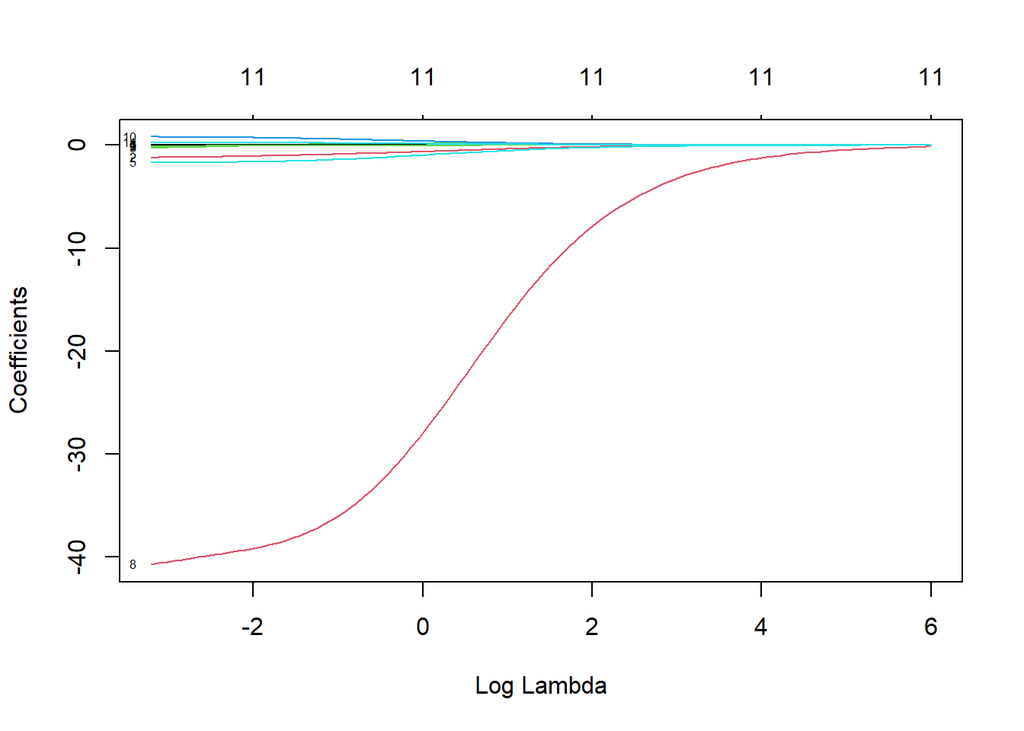

```r
set.seed(11)

x = model.matrix(quality~.-1,data=wine_data_train)
y = wine_data_train$quality

fit_ridge = glmnet(x, y, alpha = 0)
plot(fit_ridge, xvar = "lambda", label = TRUE)
```

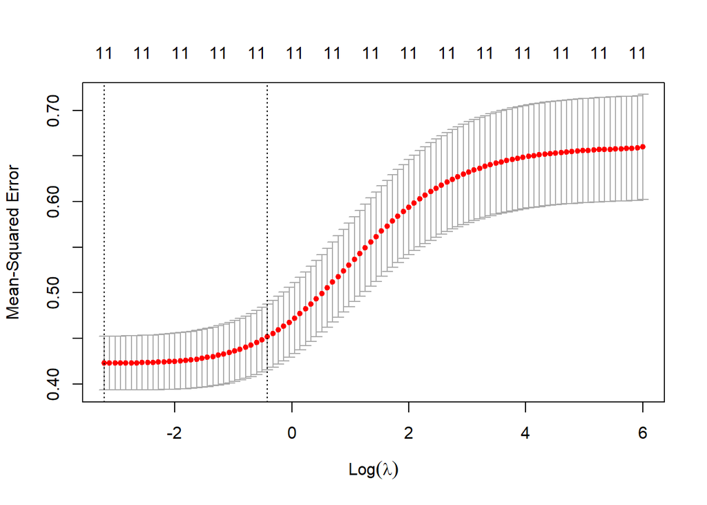

```r
cv_ridge = cv.glmnet(x, y, alpha = 0)
plot(cv_ridge)
```

```r
cv_ridge$lambda.min
```

```
## [1] 0.04044944
```

```r
ridge_predictions <- predict(cv_ridge, newx = model.matrix(quality~.-1,data=wine_data_test), s = "lambda.min")
RMSE(ridge_predictions, wine_data_test$quality)
```

```
## [1] 0.6571865
```

Based on the 10-fold cross validation used above, the hyperparameter chosen is $λ = 0.04044944$ which produced a training $MSE ≃ 0.43$. This fitted model has nearly the same test error, $MSE = 0.432$.

**(c) Fit a lasso model on the training set, with hyperparameter** $λ$ **chosen by cross-validation.**

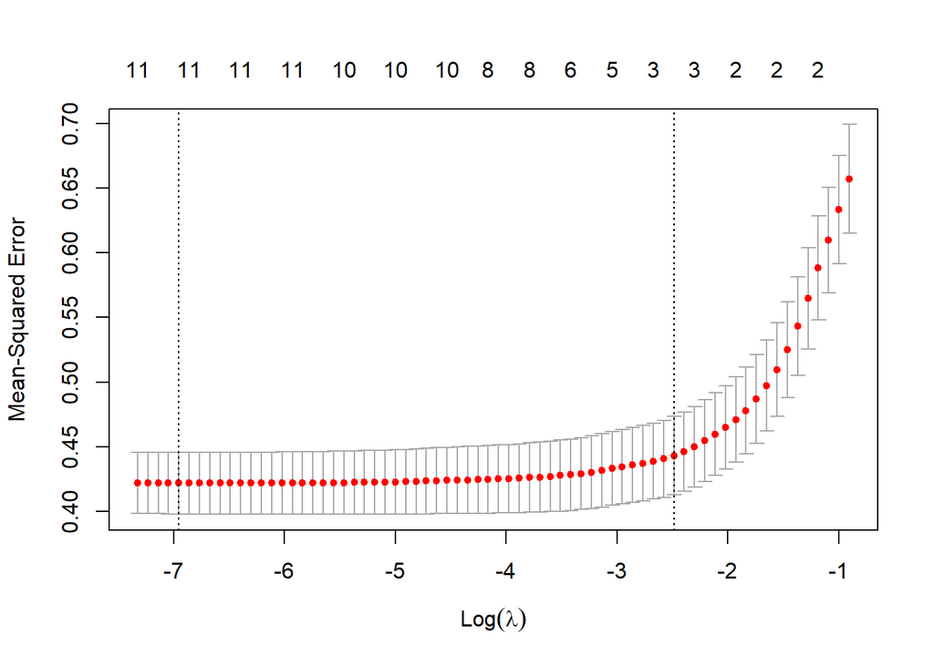

```r
fit_lasso = glmnet(x, y, alpha = 1)
#plot(fit_lasso, xvar = "lambda", label = TRUE)

cv_lasso = cv.glmnet(x, y, alpha = 1)
plot(cv_lasso)
```

```r
cv_lasso$lambda.min
```

```
## [1] 0.0009564227
```

```r
cv_lasso$lambda.1se
```

```
## [1] 0.08318477
```

```r
coef(cv_lasso, s = "lambda.1se")
```

```
## 12 x 1 sparse Matrix of class "dgCMatrix"
##                               1
## (Intercept)           3.1993870
## fixed.acidity         .
## volatile.acidity     -1.0117085
## citric.acid           .
## residual.sugar        .
## chlorides             .
## free.sulfur.dioxide   .
## total.sulfur.dioxide  .
## density               .
## pH                    .
## sulphates             0.1956939
## alcohol               0.2744823
```

```r
lasso_predictions <- predict(cv_lasso, newx = model.matrix(quality~.-1,data=wine_data_test), s = "lambda.1se")
RMSE(lasso_predictions, wine_data_test$quality)
```

```
## [1] 0.6733559
```

Based on the cross-validation used above, the chosen hyperparameter is $λ = 0.08318477$. The ‘one standard error’ fit is chosen, rather than the minimum, as the minimum includes all 11 covariates while the chosen model only includes 3. Since the errors are fairly similar, it makes sense to go with a simpler model with higher interpretability. This reduced fitted model has a test error of $MSE = 0.4534$.

**(d) Use regsubsets to choose the best linear model using forward and backward stepwise regression.**

Forward fit on training data.

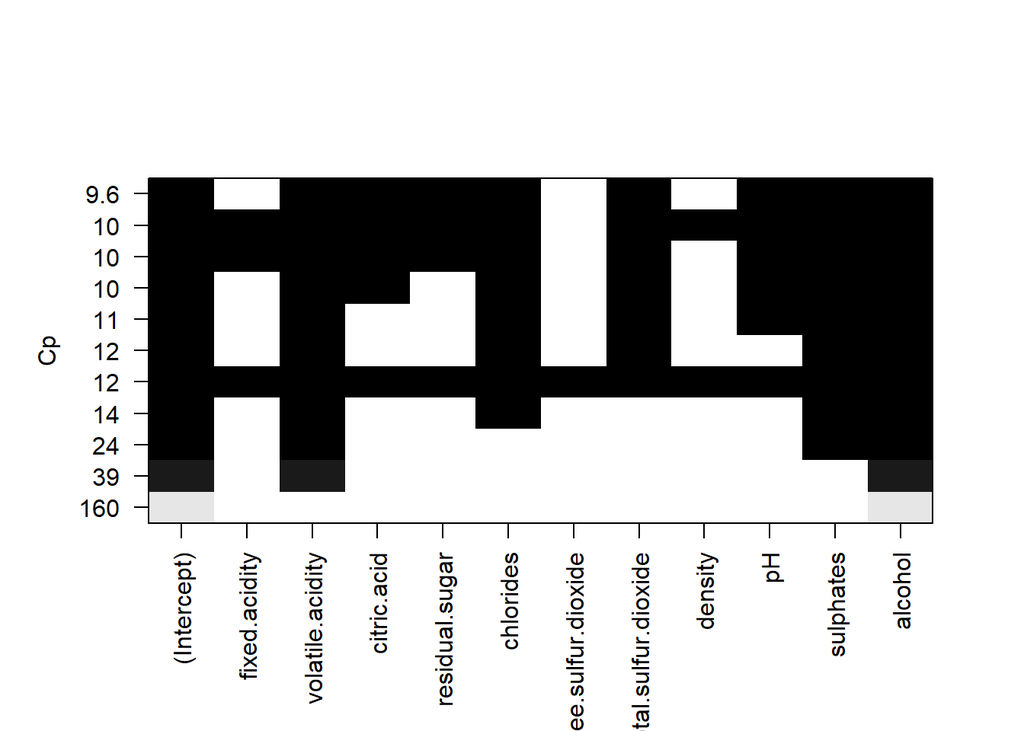

```r
set.seed(5)

fit_regforward = regsubsets(quality~., data = wine_data_train, nvmax = 11, method = "forward")
plot(fit_regforward, scale="Cp")
```

```r
summary(fit_regforward)
```

```
## Subset selection object
## Call: regsubsets.formula(quality ~ ., data = wine_data_train, nvmax = 11,
##     method = "forward")
## 11 Variables  (and intercept)
##                      Forced in Forced out
## fixed.acidity            FALSE      FALSE
## volatile.acidity         FALSE      FALSE
## citric.acid              FALSE      FALSE
## residual.sugar           FALSE      FALSE
## chlorides                FALSE      FALSE
## free.sulfur.dioxide      FALSE      FALSE
## total.sulfur.dioxide     FALSE      FALSE
## density                  FALSE      FALSE
## pH                       FALSE      FALSE
## sulphates                FALSE      FALSE
## alcohol                  FALSE      FALSE
## 1 subsets of each size up to 11
## Selection Algorithm: forward
##           fixed.acidity volatile.acidity citric.acid residual.sugar chlorides
## 1  ( 1 )  " "           " "              " "         " "            " "
## 2  ( 1 )  " "           "*"              " "         " "            " "
## 3  ( 1 )  " "           "*"              " "         " "            " "
## 4  ( 1 )  " "           "*"              " "         " "            "*"
## 5  ( 1 )  " "           "*"              " "         " "            "*"
## 6  ( 1 )  " "           "*"              " "         " "            "*"
## 7  ( 1 )  " "           "*"              "*"         " "            "*"
## 8  ( 1 )  " "           "*"              "*"         "*"            "*"
## 9  ( 1 )  "*"           "*"              "*"         "*"            "*"
## 10  ( 1 ) "*"           "*"              "*"         "*"            "*"
## 11  ( 1 ) "*"           "*"              "*"         "*"            "*"
##           free.sulfur.dioxide total.sulfur.dioxide density pH  sulphates
## 1  ( 1 )  " "                 " "                  " "     " " " "
## 2  ( 1 )  " "                 " "                  " "     " " " "
## 3  ( 1 )  " "                 " "                  " "     " " "*"
## 4  ( 1 )  " "                 " "                  " "     " " "*"
## 5  ( 1 )  " "                 "*"                  " "     " " "*"
## 6  ( 1 )  " "                 "*"                  " "     "*" "*"
## 7  ( 1 )  " "                 "*"                  " "     "*" "*"
## 8  ( 1 )  " "                 "*"                  " "     "*" "*"
## 9  ( 1 )  " "                 "*"                  " "     "*" "*"
## 10  ( 1 ) " "                 "*"                  "*"     "*" "*"
## 11  ( 1 ) "*"                 "*"                  "*"     "*" "*"
##           alcohol
## 1  ( 1 )  "*"
## 2  ( 1 )  "*"
## 3  ( 1 )  "*"
## 4  ( 1 )  "*"
## 5  ( 1 )  "*"
## 6  ( 1 )  "*"
## 7  ( 1 )  "*"
## 8  ( 1 )  "*"
## 9  ( 1 )  "*"
## 10  ( 1 ) "*"
## 11  ( 1 ) "*"
```

Backward stepwise selection on training data.

[figure not shown]

```r
fit_regbackward = regsubsets(quality~., data = wine_data_train, nvmax = 11, method = "backward")
plot(fit_regforward, scale="Cp")
```

```r
summary(fit_regbackward)
```

```
## Subset selection object
## Call: regsubsets.formula(quality ~ ., data = wine_data_train, nvmax = 11,
##     method = "backward")
## 11 Variables  (and intercept)
##                      Forced in Forced out
## fixed.acidity            FALSE      FALSE
## volatile.acidity         FALSE      FALSE
## citric.acid              FALSE      FALSE
## residual.sugar           FALSE      FALSE
## chlorides                FALSE      FALSE
## free.sulfur.dioxide      FALSE      FALSE
## total.sulfur.dioxide     FALSE      FALSE
## density                  FALSE      FALSE
## pH                       FALSE      FALSE
## sulphates                FALSE      FALSE
## alcohol                  FALSE      FALSE
## 1 subsets of each size up to 11
## Selection Algorithm: backward
##           fixed.acidity volatile.acidity citric.acid residual.sugar chlorides
## 1  ( 1 )  " "           " "              " "         " "            " "
## 2  ( 1 )  " "           "*"              " "         " "            " "
## 3  ( 1 )  " "           "*"              " "         " "            " "
## 4  ( 1 )  " "           "*"              " "         " "            "*"
## 5  ( 1 )  "*"           "*"              " "         " "            "*"
## 6  ( 1 )  "*"           "*"              "*"         " "            "*"
## 7  ( 1 )  "*"           "*"              "*"         "*"            "*"
## 8  ( 1 )  "*"           "*"              "*"         "*"            "*"
## 9  ( 1 )  "*"           "*"              "*"         "*"            "*"
## 10  ( 1 ) "*"           "*"              "*"         "*"            "*"
## 11  ( 1 ) "*"           "*"              "*"         "*"            "*"
##           free.sulfur.dioxide total.sulfur.dioxide density pH  sulphates
## 1  ( 1 )  " "                 " "                  " "     " " " "
## 2  ( 1 )  " "                 " "                  " "     " " " "
## 3  ( 1 )  " "                 " "                  " "     " " "*"
## 4  ( 1 )  " "                 " "                  " "     " " "*"
## 5  ( 1 )  " "                 " "                  " "     " " "*"
## 6  ( 1 )  " "                 " "                  " "     " " "*"
## 7  ( 1 )  " "                 " "                  " "     " " "*"
## 8  ( 1 )  " "                 " "                  "*"     " " "*"
## 9  ( 1 )  " "                 "*"                  "*"     " " "*"
## 10  ( 1 ) " "                 "*"                  "*"     "*" "*"
## 11  ( 1 ) "*"                 "*"                  "*"     "*" "*"
##           alcohol
## 1  ( 1 )  "*"
## 2  ( 1 )  "*"
## 3  ( 1 )  "*"
## 4  ( 1 )  "*"
## 5  ( 1 )  "*"
## 6  ( 1 )  "*"
## 7  ( 1 )  "*"
## 8  ( 1 )  "*"
## 9  ( 1 )  "*"
## 10  ( 1 ) "*"
## 11  ( 1 ) "*"
```

Evaluating the test MSE for all variable lengths from forward selection fit.

```r
test_matrix_f = model.matrix(quality∼., data = wine_data_test)

test_errors_f = rep(NA ,11)
  for(i in 1:11){
  coefi = coef(fit_regforward, id = i)
  pred = test_matrix_f[,names(coefi)]%*%coefi
  test_errors_f[i] = mean((wine_data_test$quality-pred)^2)
  }

test_errors_f
```

```
##  [1] 0.5172860 0.4625442 0.4479558 0.4441685 0.4364971 0.4316717 0.4321277
##  [8] 0.4335663 0.4346685 0.4360471 0.4353725
```

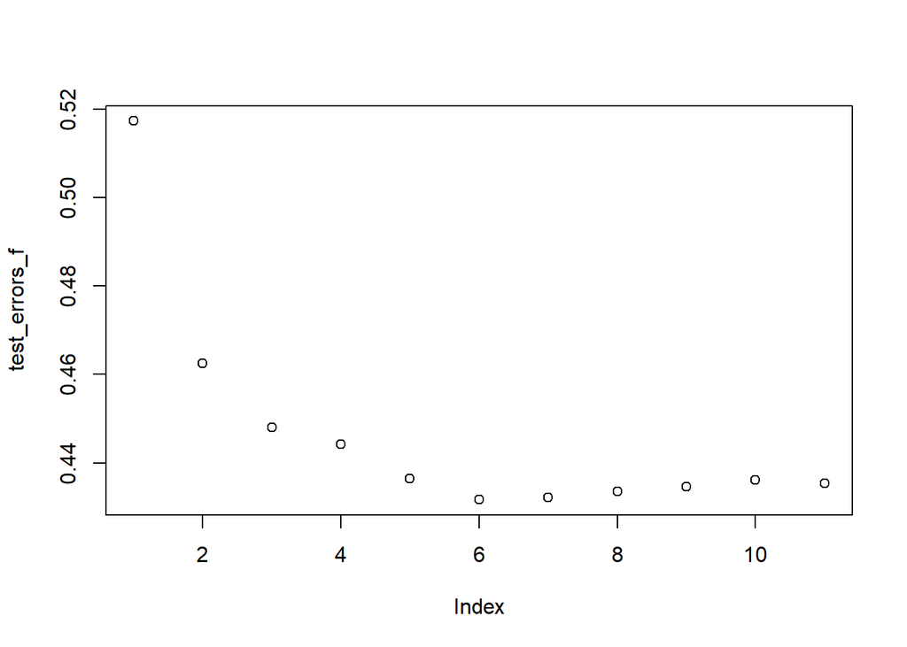

```r
plot(test_errors_f)
```

```r
which.min(test_errors_f)
```

```
## [1] 6
```

```r
coef(fit_regforward, 6)
```

```
##          (Intercept)     volatile.acidity            chlorides
##          3.613989652         -1.164320018         -1.931211425
## total.sulfur.dioxide                   pH            sulphates
##         -0.001562609         -0.282287598          0.779522529
##              alcohol
##          0.318799766
```

For forward selection, the six variable model has the lowest error.

Evaluating the test MSE for all variable lengths from backward selection fit.

```r
x = model.matrix(quality~.-1,data=wine_data_train)
y = wine_data_train$quality

test_matrix_b = model.matrix(quality∼., data = wine_data_test)

test_errors_b = rep(NA ,11)
  for(i in 1:11){
  coefi = coef(fit_regbackward, id = i)
  pred = test_matrix_b[,names(coefi)]%*%coefi
  test_errors_b[i] = mean((wine_data_test$quality-pred)^2)
  }

test_errors_b
```

```
##  [1] 0.5172860 0.4625442 0.4479558 0.4441685 0.4413009 0.4415152 0.4434202
##  [8] 0.4425844 0.4365827 0.4360471 0.4353725
```

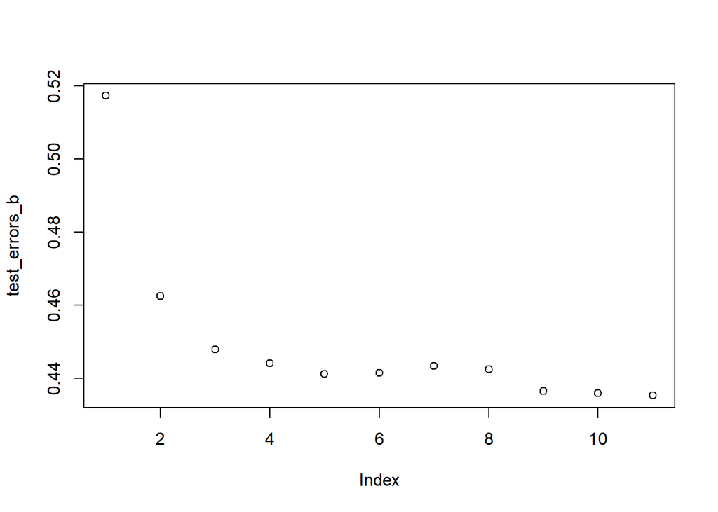

```r
plot(test_errors_b)
```

```r
which.min(test_errors_b)
```

```
## [1] 11
```

Using forward selection, the best model is reduced to only six variables, with an error of $MSE = 0.433$. However, with backward selection, the best model includes all eleven variables, with an error of $MSE = 0.435$. The forward selection model is chosen since the model contains fewer variables, and is therefore a little easier to interpret.

**(3) Comment on the results obtained. How accurately can we predict wine quality? Is there much difference among the test errors resulting from these approaches? Are the models themselves similar?**

The linear model had an MSE test error of $0.43$. It identified six significant variables with p-values $\le 0.05$ (three highly significant with p-values $\le 0.001$).

The ridge model had an MSE of $0.43$ and, of course, included all eleven variables.

The lasso model had an MSE of $0.45$ and included three variables, the same three that were shown to have the highest significance in the linear model (p-values $\le 0.001$).

The model from using backward stepwise selection had an MSE of $0.43$ and included all eleven variables.

The best model is the three-variable model chosen by lasso, as it has a similar MSE as the others ($~0.02$ difference) and has far fewer variables than the others. All of the models have similar errors, all models included the three highly significant variables included in lasso, but the other models include insignificant variables with little improvement in predictability.

### Question 3

**(a) Generate a simulated data set. What is $n$ and what is $p$? Write out the model used to generate the data in equation form.**

```r
set.seed(1)

X <- rnorm(100)
Y <- X - 2 * X^2 + rnorm(100)
```

$$n = 100$$

$$p = 2$$

$$Y = X - 2X^2 + \varepsilon$$

**(b) Create a scatterplot of $X$ against $Y$. Comment on what you find.**

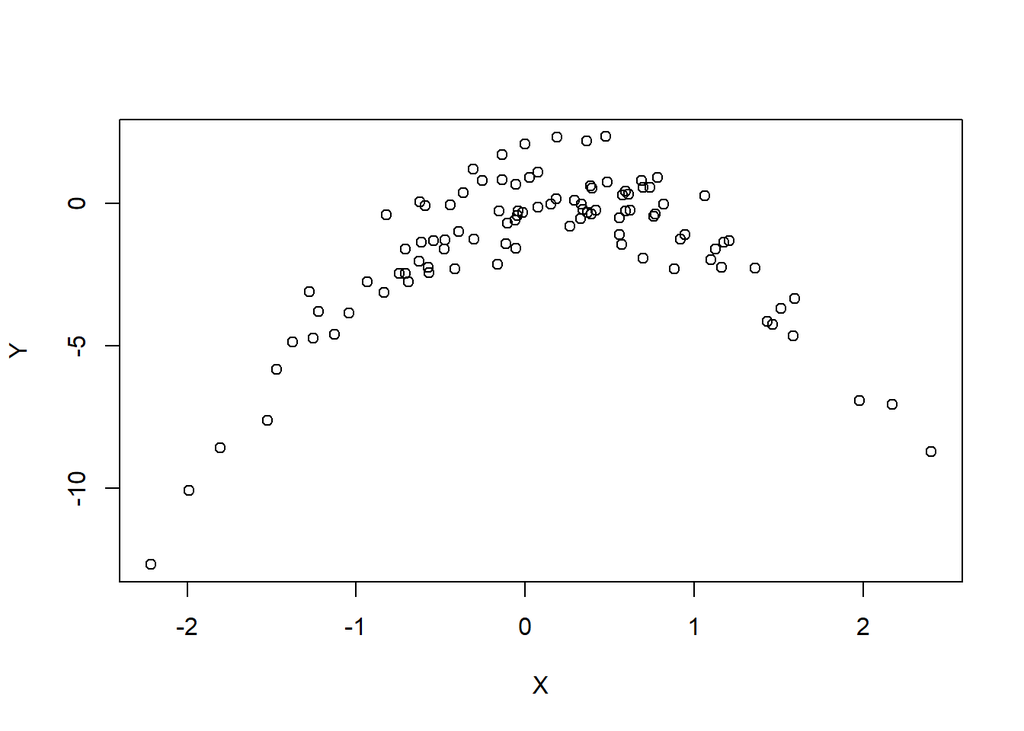

```r
plot(X, Y)
```

Clearly there is a non-linear relationship, a negative quadratic shape. Of course, these points were generated from a negative quadratic equation so this is expected.

**(c) Set a random seed, and then compute the LOOCV errors that result from fitting the following four models using least squares:**

$i. Y = \beta_{0} + \beta_{1}X + \varepsilon$

```r
set.seed(2)

df <- data.frame(X, Y)

train.control <- trainControl(method = "LOOCV")

model1 <- train(Y ~ X, data = df, method = "lm", trControl = train.control)

print(model1)
```

```
## Linear Regression
##
## 100 samples
##   1 predictor
##
## No pre-processing
## Resampling: Leave-One-Out Cross-Validation
## Summary of sample sizes: 99, 99, 99, 99, 99, 99, ...
## Resampling results:
##
##   RMSE     Rsquared    MAE
##   2.69966  0.00130345  1.921879
##
## Tuning parameter 'intercept' was held constant at a value of TRUE
```

$ii. Y = \beta_{0} + \beta_{1}X + \beta_{2}X^2 + \varepsilon$

```r
model2 <- train(Y ~ poly(X, 2), data = df, method = "lm", trControl = train.control)

print(model2)
```

```
## Linear Regression
##
## 100 samples
##   1 predictor
##
## No pre-processing
## Resampling: Leave-One-Out Cross-Validation
## Summary of sample sizes: 99, 99, 99, 99, 99, 99, ...
## Resampling results:
##
##   RMSE       Rsquared   MAE
##   0.9682064  0.8663108  0.7829438
##
## Tuning parameter 'intercept' was held constant at a value of TRUE
```

$iii. Y = \beta_{0} + \beta_{1}X + \beta_{2}X^2 + \beta_{3}X^3 + \varepsilon$

```r
model3 <- train(Y ~ poly(X, 3), data = df, method = "lm", trControl = train.control)

print(model3)
```

```
## Linear Regression
##
## 100 samples
##   1 predictor
##
## No pre-processing
## Resampling: Leave-One-Out Cross-Validation
## Summary of sample sizes: 99, 99, 99, 99, 99, 99, ...
## Resampling results:
##
##   RMSE       Rsquared   MAE
##   0.9780705  0.8637902  0.7924894
##
## Tuning parameter 'intercept' was held constant at a value of TRUE
```

$iv. Y = \beta_{0} + \beta_{1}X + \beta_{2}X^2 + \beta_{3}X^3 + \beta_{4}X^4 + \varepsilon$

```r
model4 <- train(Y ~ poly(X, 4), data = df, method = "lm", trControl = train.control)

print(model4)
```

```
## Linear Regression
##
## 100 samples
##   1 predictor
##
## No pre-processing
## Resampling: Leave-One-Out Cross-Validation
## Summary of sample sizes: 99, 99, 99, 99, 99, 99, ...
## Resampling results:
##
##   RMSE       Rsquared   MAE
##   0.9766805  0.8639008  0.8019279
##
## Tuning parameter 'intercept' was held constant at a value of TRUE
```

**(d) Repeat (c) using another random seed, and report your results. Are your results the same as what you got in (c)? Why?**

```r
set.seed(50)

model5 <- train(Y ~ X, data = df, method = "lm", trControl = train.control)
model6 <- train(Y ~ poly(X, 2), data = df, method = "lm", trControl = train.control)
model7 <- train(Y ~ poly(X, 3), data = df, method = "lm", trControl = train.control)
model8 <- train(Y ~ poly(X, 4), data = df, method = "lm", trControl = train.control)

print(model5)
```

```
## Linear Regression
##
## 100 samples
##   1 predictor
##
## No pre-processing
## Resampling: Leave-One-Out Cross-Validation
## Summary of sample sizes: 99, 99, 99, 99, 99, 99, ...
## Resampling results:
##
##   RMSE     Rsquared    MAE
##   2.69966  0.00130345  1.921879
##
## Tuning parameter 'intercept' was held constant at a value of TRUE
```

```r
print(model6)
```

```
## Linear Regression
##
## 100 samples
##   1 predictor
##
## No pre-processing
## Resampling: Leave-One-Out Cross-Validation
## Summary of sample sizes: 99, 99, 99, 99, 99, 99, ...
## Resampling results:
##
##   RMSE       Rsquared   MAE
##   0.9682064  0.8663108  0.7829438
##
## Tuning parameter 'intercept' was held constant at a value of TRUE
```

```r
print(model7)
```

```
## Linear Regression
##
## 100 samples
##   1 predictor
##
## No pre-processing
## Resampling: Leave-One-Out Cross-Validation
## Summary of sample sizes: 99, 99, 99, 99, 99, 99, ...
## Resampling results:
##
##   RMSE       Rsquared   MAE
##   0.9780705  0.8637902  0.7924894
##
## Tuning parameter 'intercept' was held constant at a value of TRUE
```

```r
print(model8)
```

```
## Linear Regression
##
## 100 samples
##   1 predictor
##
## No pre-processing
## Resampling: Leave-One-Out Cross-Validation
## Summary of sample sizes: 99, 99, 99, 99, 99, 99, ...
## Resampling results:
##
##   RMSE       Rsquared   MAE
##   0.9766805  0.8639008  0.8019279
##
## Tuning parameter 'intercept' was held constant at a value of TRUE
```

The results are the same as in (c) despite a different seed. This is because in the LOOCV procedure, there are $n$ folds, meaning every data point is tested against a fit of $n-1$ points. If the data has not changed, then the resulting errors will be same each time LOOCV is run.

**(e) Which of the models in (c) had the smallest LOOCV error? Is this what you expected? Explain your answer.**

The second model, the quadratic, had the lowest LOOCV error of $RMSE = 0.968$ (or $MSE = 0.937$). This shows that LOOCV chose the correct model, given that the data generating process is a quadratic.

**(f) Comment on the statistical significance of the coefficient estimates that results from fitting each of the models in (c) using least squares. Do these results agree with the conclusions drawn based on the cross-validation results?**

```r
summary(model4)
```

```
##
## Call:
## lm(formula = .outcome ~ ., data = dat)
##
## Residuals:
##     Min      1Q  Median      3Q     Max
## -2.0550 -0.6212 -0.1567  0.5952  2.2267
##
## Coefficients:
##                Estimate Std. Error t value Pr(>|t|)
## (Intercept)    -1.55002    0.09591 -16.162  < 2e-16 ***
## `poly(X, 4)1`   6.18883    0.95905   6.453 4.59e-09 ***
## `poly(X, 4)2` -23.94830    0.95905 -24.971  < 2e-16 ***
## `poly(X, 4)3`   0.26411    0.95905   0.275    0.784
## `poly(X, 4)4`   1.25710    0.95905   1.311    0.193
## ---
## Signif. codes:  0 '***' 0.001 '**' 0.01 '*' 0.05 '.' 0.1 ' ' 1
##
## Residual standard error: 0.9591 on 95 degrees of freedom
## Multiple R-squared:  0.8753, Adjusted R-squared:  0.8701
## F-statistic: 166.7 on 4 and 95 DF,  p-value: < 2.2e-16
```

Based on the above p-values for each coefficient, only the linear and quadratic variables are statistically significant, which is consistent with the LOOCV error being lowest for the quadratic equation.

### Question 4

**(1) Load the data GWAS.csv, and split it into equal-sized testing and training datasets. The first column is the indicator function of a disease. The remaining columns are indicator functions for a collection of alleles that have been studied. Fit a standard logistic regression model to the training set and apply to the testing set. Summarize the model fit and the performance of the model on the test data.**

Random splitting into equal-sized train and test data sets (with stratified V1).

```r
GWAS_data = read.csv("GWAS.csv")
GWAS_data = GWAS_data[,-1]

set.seed(105)

i <- createDataPartition(GWAS_data$V1, p = .5,
                                  list = FALSE,
                                  times = 1)
GWAS_data_train <- GWAS_data[i,]
GWAS_data_test <- GWAS_data[-i,]

nrow(GWAS_data_train)
```

```
## [1] 1500
```

```r
nrow(GWAS_data_test)
```

```
## [1] 1500
```

```r
summary(GWAS_data_train$V1)
```

```
##    Min. 1st Qu.  Median    Mean 3rd Qu.    Max.
##  0.0000  0.0000  0.0000  0.3647  1.0000  1.0000
```

```r
fit_log = glm(V1~., data = GWAS_data_train, family=binomial)

predictions_log = predict(fit_log, data = GWAS_data_test, type="response")
predictions_log[1:10]
```

```
##          1          4          5          9         10         12         14
## 0.14405577 0.19676427 0.44765958 0.20493778 0.41158832 0.08705343 0.39070157
##         17         21         22
## 0.01293019 0.63403050 0.85640484
```

```r
RMSE(predictions_log, GWAS_data_test$V1)
```

```
## [1] 0.5682647
```

```r
predictions_log = ifelse(predictions_log > 0.5, 1, 0)
```

```r
table(predictions_log, V1)
```

```
##                V1
## predictions_log   0   1
##               0 646 340
##               1 335 179
```

```r
mean(predictions_log == V1)
```

```
## [1] 0.55
```

$Accuracy: 0.55$

$Error: 0.45$

$Precision: 179/(179 + 335) = 0.348$

$Recall/sensitivity: 179/(179 + 340) = 0.345$

$Negative Predictive Value = 646/(646 + 340) = 0.655$

The accuracy of the logisitic regression model is 55%, which is close to chance given a binary dependent variable. Precision and recall are poor (~34%), while negative predictive value is better (~65%). It might appear that the model does a better job than ‘chance’ at predicting negative outcomes, but our data is imbalanced and skewed towards negative outcomes (~65% of our test set). Comparing the class proportions between the data and predictions, they are basically the same (65/35 split in the data set, and 66/34 split in predicted values).

**(2) Repeat the previous step, but this time use Lasso or ridge regression. Compare the results.**

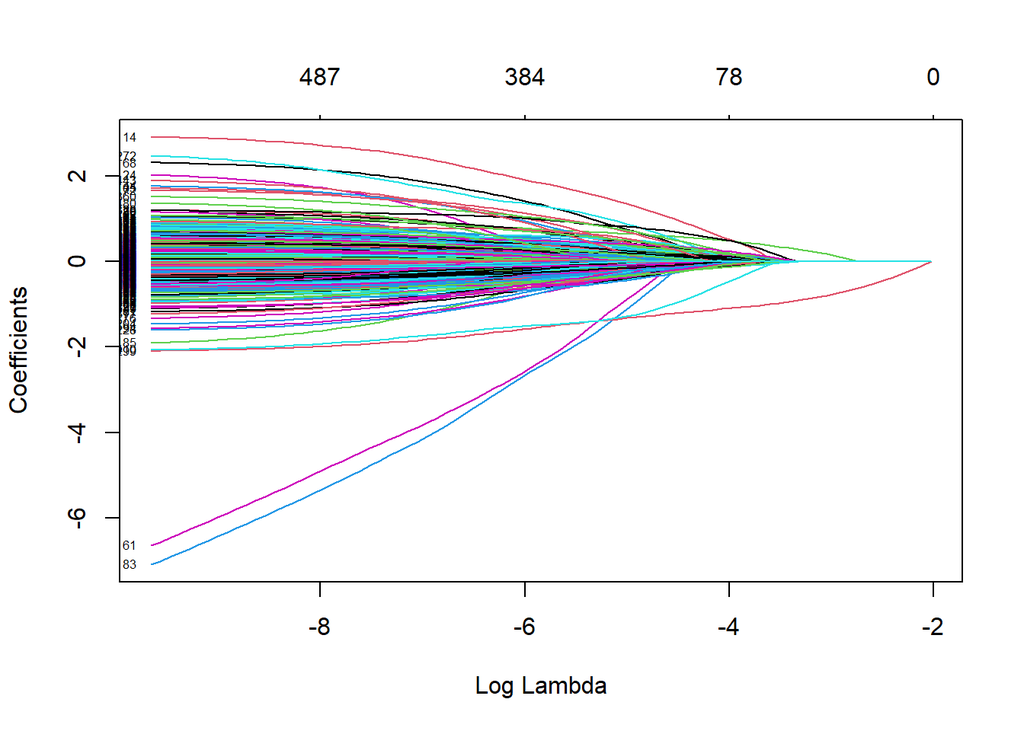

```r
x = model.matrix(V1~.-1, data = GWAS_data_train)
y = GWAS_data_train$V1

fit_lasso_log = glmnet(x, y, alpha = 1, family = "binomial")

plot(fit_lasso_log, xvar = "lambda", label = TRUE)
```

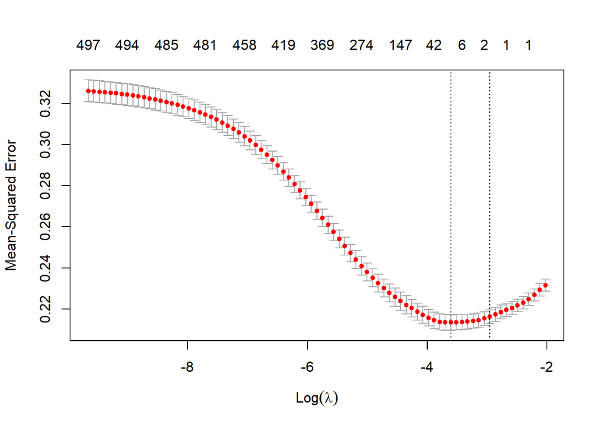

```r
cv_lasso_log = cv.glmnet(x, y, alpha = 1)

plot(cv_lasso_log)
```

```r
#coef(cv_lasso_log, s = "lambda.min")

lasso_predictions_log <- predict(cv_lasso_log, newx = model.matrix(V1~.-1,data=GWAS_data_test), s = "lambda.min")
lasso_predictions_log = ifelse(lasso_predictions_log > 0.5, 1, 0)
```

```r
table(lasso_predictions_log, V1)
```

```
##                      V1
## lasso_predictions_log   0   1
##                     0 922 434
##                     1  59  85
```

```r
mean(lasso_predictions_log == V1)
```

```
## [1] 0.6713333
```

$Accuracy: 0.671$

$Error: 0.329$

$Precision: 85/(85 + 59) = 0.59$

$Recall/sensitivity: 85/(85 + 434) = 0.164$

$Negative Predictive Value = 922/(922 + 434) = 0.68$

The improvement is due to the model predicting negative more often than the previous model (90% of predictions were negative, compared to 66%). Interestingly, the ‘one standard error’ model that is chosen by default for this CV fit reduced the model to only two variables, and guessed negative 100% of the time. The accuracy was exactly proportionate to the number of negative cases in the data (65%). A similar predictive pattern is seen here.

**(3) Draw an estimate of the ROC curve for the best method you used. Describe any interesting features.**

I will naively chose the lasso model based on higher accuracy alone. I will not assume any domain-specific preference for certain evaluation metrics in this part.

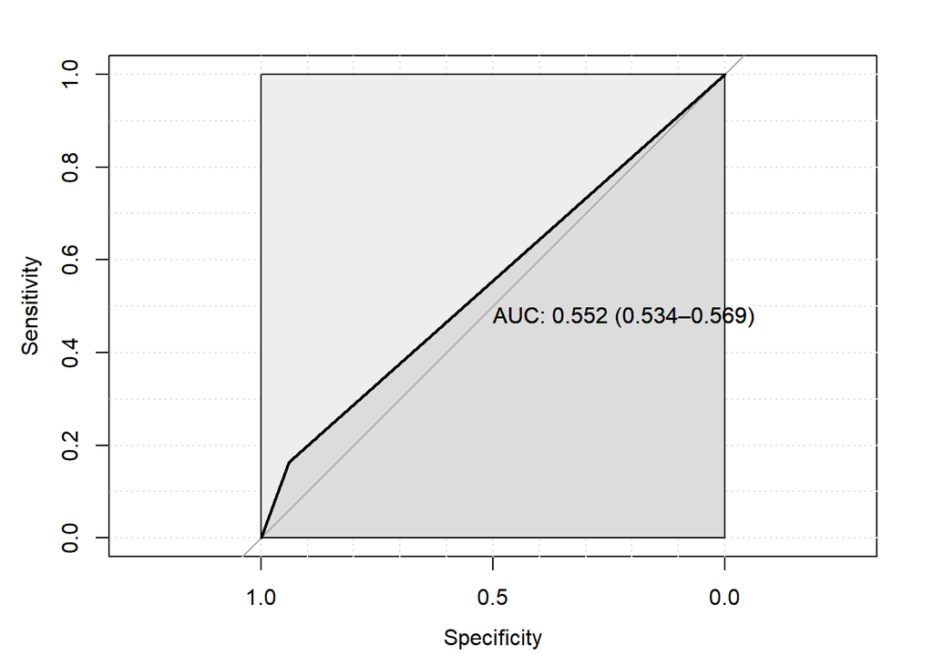

```r
roc_curve <- roc(GWAS_data_test$V1, lasso_predictions_log,
            smoothed = TRUE,
            ci=TRUE, ci.alpha=0.9, stratified=FALSE,
            plot=TRUE, auc.polygon=TRUE, max.auc.polygon=TRUE, grid=TRUE,
            print.auc=TRUE, show.thres=TRUE)
```

The curve does not have a strong arc and is nearing the middle line, which indicates a “no information” model (unable to differentiate positive cases). It is (slightly) better than the previous model below.

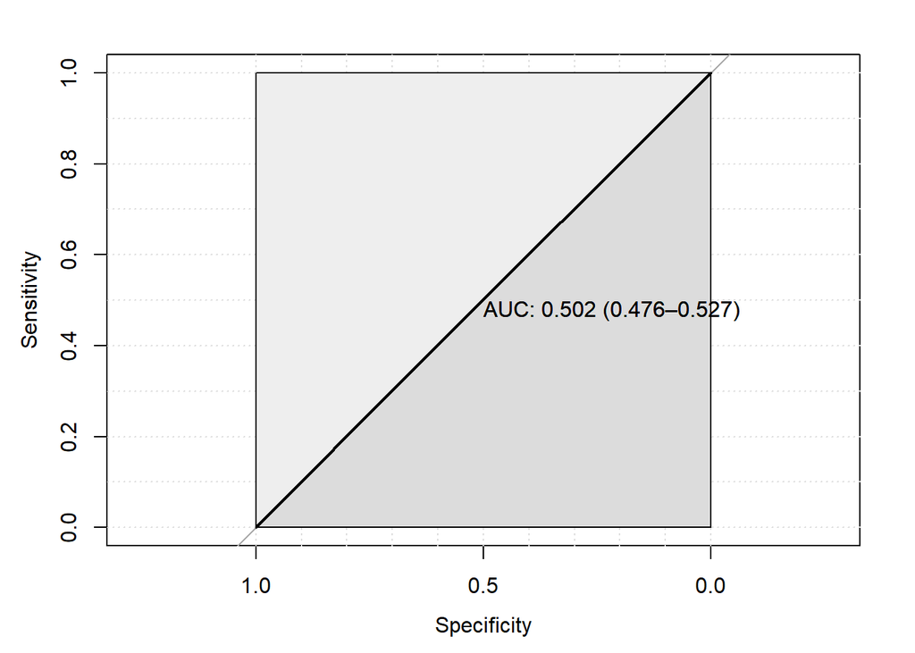

```r
roc_curve2 <- roc(GWAS_data_test$V1, predictions_log,
            smoothed = TRUE,
            ci=TRUE, ci.alpha=0.9, stratified=FALSE,
            plot=TRUE, auc.polygon=TRUE, max.auc.polygon=TRUE, grid=TRUE,
            print.auc=TRUE, show.thres=TRUE)
```

**(4) You wish to use your model for screening. This means measuring a small number of variables, then forwarding a small fraction of people for further testing. Based on funding considerations, you wish to forward roughly 1 percent of the population for further testing. Describe a decision procedure based on the model you used in the previous step. Does the plotted ROC curve influence your choice?**

Generally, a model with a low recall/sensitivity is considered dangerous for screening for life-critical disease. However, given that the purpose of this prediction is to send only one percent of the tested population for further testing, I would argue that precision is a more important metric. It is more important that those sent for testing are actually positive cases, rather than attempting to detect every positive case in our test population. Based on the above test results, ~10% of the test population were predicted positive, and of those, 59% were actually positive, which is better than a chance guess based on the prior for positive cases (~35% of the population based on this data). This gives us a ~5% true positive, well above the 1% needed (assuming the data is reflective of the general population), so it is seemingly capable of detecting enough true positives for this purpose. Based on this preference for precision over recall/sensitivity, the lasso model is better (59% precision compared to 35% for the other model).

Furthermore, the lasso model has far fewer variables - 16 compared to 500. This is certainly an important consideration if one can only measure a small number of variables for testing. The ROC curve does not tell us a lot given that it is not strongly curved, but having some arc here is better than none, given that a higher recall/sensitivity is ideal.

### Question 5

**I begin by describing the dataset and the problem. Load the dataset SchoolCorrect.csv and display some parts of it. The rows correspond to student, and each student i comes with the following information:**

**(1) The school they belong to (from 1 to 6), which I will denote** $S_i$.

**(2) The student’s test score on a standardized test after some standardization/centering, which I will denote** $T_i$.

**To set notation, I will denote by** $N(j) = {i : S_i = j}$ **the students in school** $j$**. The scientific questions we will try to answer are: which school is the “best,” and how confident are we in our comparisons?**

```r
set.seed(1)

school_data = read.csv("SchoolCorrect.csv")
head(school_data)
```

```
##   School.ID Test.Score
## 1         1   2.507780
## 2         1  10.593256
## 3         1  10.726132
## 4         1  -9.128713
## 5         1  -1.762036
## 6         1   6.106852
```

```r
nrow(school_data)
```

```
## [1] 7374
```

```r
test_scores <- school_data$Test.Score
#test_scores
```

**(1) We will start with naive estimates. For each school** $j ∈ {1, 2, . . . , 6}$**, fit the simple model**

$$T_i ∼ N(β_j, 5^2), i ∈ N(j).$$
**This model has 1 parameter,** $β_j$**, and there are 6 schools, so in total you should be estimating (1)(6) = 6 parameters in this part of the question. Finally, rank the schools according to the magnitude of** $β_j$**.**

```r
means<-data.frame(rep(1:6),rep(0,6), rep(0,6), rep(0,6), rep(0,6), rep(0, 6))
names(means) <- c("School j", "βj Estimate", "Rank", "|N(j)|", "Corrected βj Estimate ", "Corrected Rank")
for(i in 1:6){
  means[i,2]<-mean(school_data$Test.Score[school_data$School.ID == i])
  means[i,4]<- sum(school_data$School.ID == i)
}

means[,3] = rank(-means[,2])
means
```

```
##   School j ßj Estimate Rank |N(j)| Corrected ßj Estimate  Corrected Rank
## 1        1   3.1738785    1      6                      0              0
## 2        2  -3.2548480    6     15                      0              0
## 3        3   1.9867965    3     53                      0              0
## 4        4  -2.1674934    5    300                      0              0
## 5        5  -0.2725454    4   2000                      0              0
## 6        6   2.6845104    2   5000                      0              0
```

**(2) We will next use Bayesian methods to compute “corrected” estimates. Observe that** $|N(j)|$ **varies a great deal - some schools are much bigger than others. Using Markov chain Monte Carlo or otherwise, sample from the posterior distribution and compute credible sets for** $β_1, . . . , β_6$**.**

```r
set.seed(1)

MH<-function(theta0,T,r,data,prior,likelihood){
  res = rep(theta0,T+1)


  for(i in 1:T){
    prop = res[i] + runif(1,-r,r)
    numerator = prior(prop)*likelihood(prop,data)
    denominator = prior(res[i])*likelihood(res[i],data)
    if(runif(1,0,1) < numerator/denominator){
      res[i+1] = prop
    } else{
      res[i+1] = res[i]
    }
  }
  return(res)
}

CInt<-function(sample,alpha){
  ord = sort(sample)
  n = length(sample)
  return(c(ord[floor(n*alpha/2)],ord[floor(n*(1-alpha/2))]))
}
```

```r
set.seed(1)

prior<-function(beta){
  s = runif(1, 1, 50)
  return(dnorm(beta, 0, s))
}

likelihood<-function(beta,data){
  n = length(data)
  res = 1
  for(i in 1:n) {
    res = res*dnorm(data[i]-beta,beta,5)
  }
  return(res)
}
```

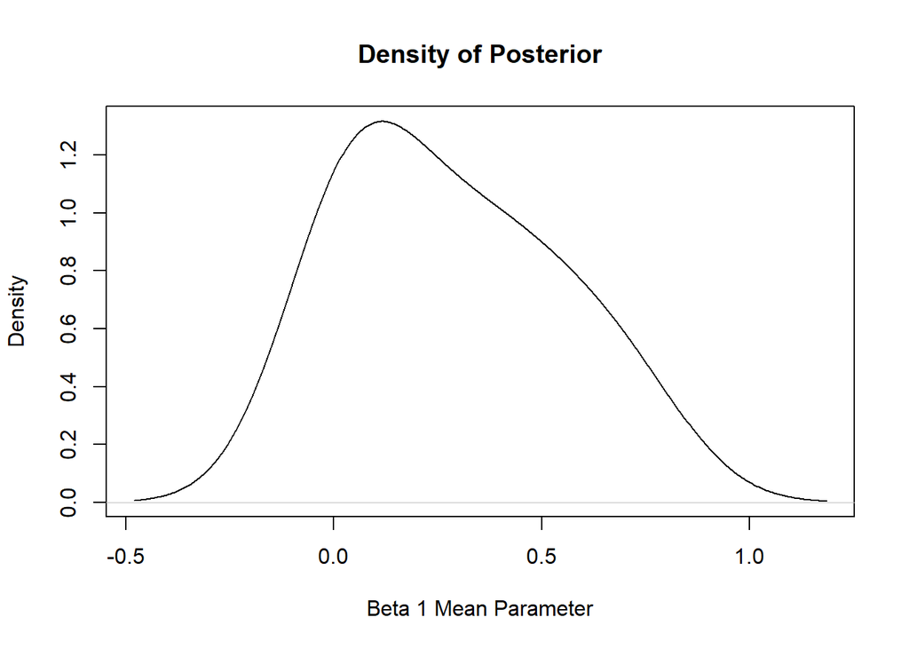

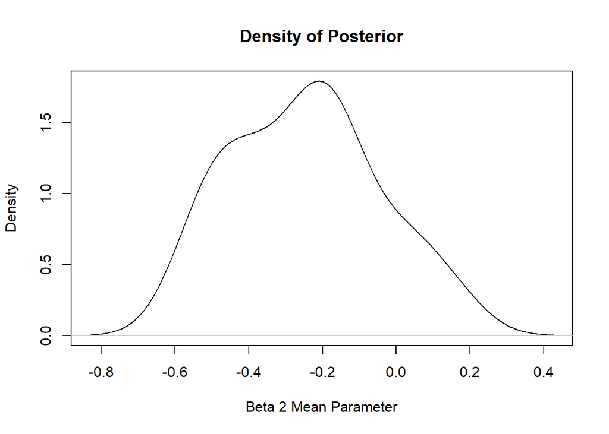

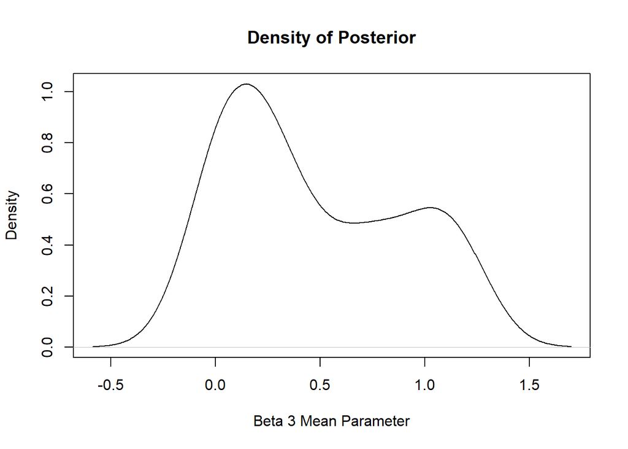

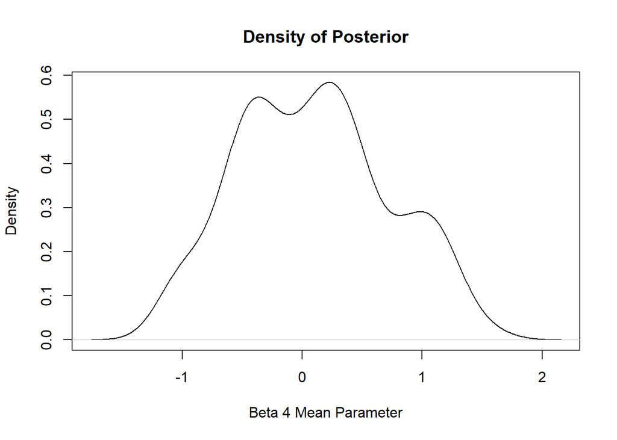

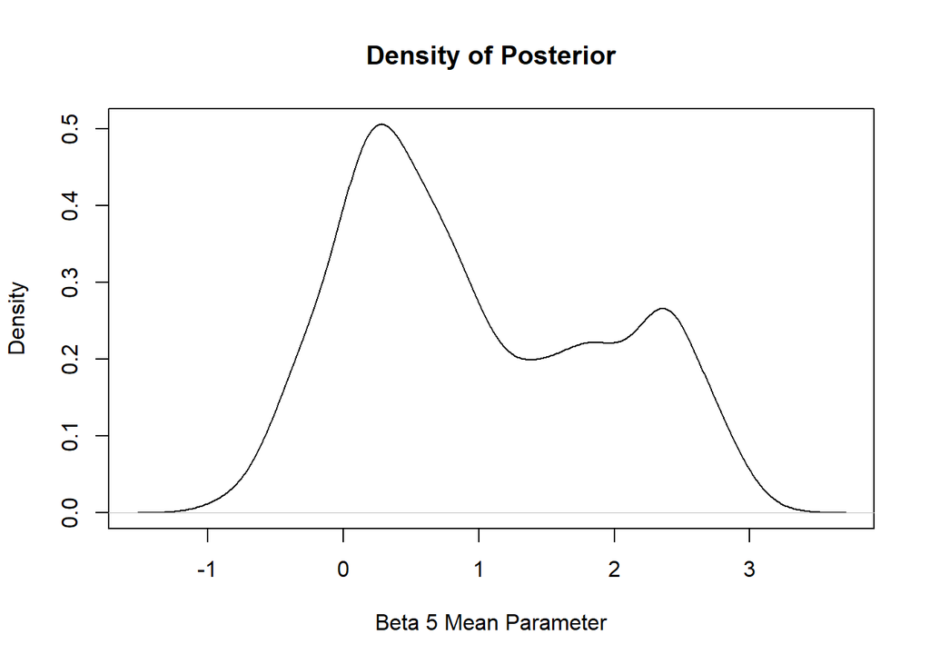

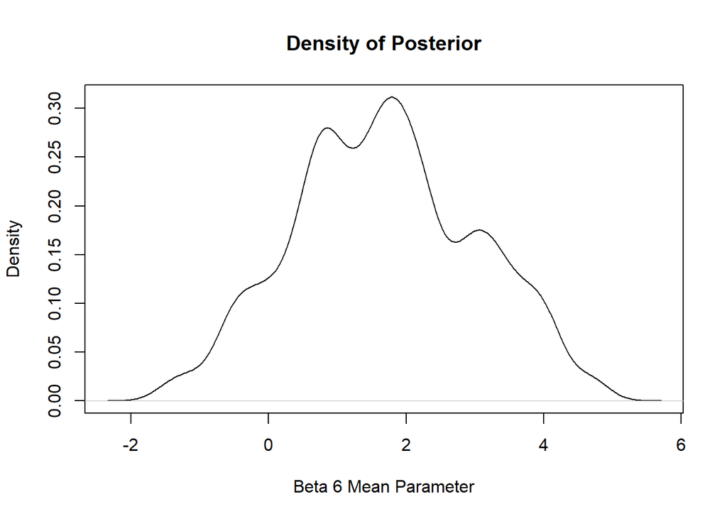

```r
set.seed(2)
for(i in 1:6){
  true_beta <- means[i,2]
  test = rnorm(10, true_beta, 5)

  T = means[i,4]
  r=0.2
  Sample = MH(0,T,r,test,prior,likelihood)
  means[i,5] <- mean(Sample)
  label = paste("Beta", i, "Mean Parameter")
  plot(density(Sample), main= "Density of Posterior", xlab=label)

}
```

```r
means
```

```
##   School j ßj Estimate Rank |N(j)| Corrected ßj Estimate  Corrected Rank
## 1        1   3.1738785    1      6             0.28132177              0
## 2        2  -3.2548480    6     15            -0.24585678              0
## 3        3   1.9867965    3     53             0.46879236              0
## 4        4  -2.1674934    5    300             0.09389005              0
## 5        5  -0.2725454    4   2000             0.97500393              0
## 6        6   2.6845104    2   5000             1.68941233              0
```

**(3) Using your samples from the posterior distribution, rank the 6 schools by the expected value of** $β_i$**. Compare this ranking to the naive estimate from part 1 of the question.**

```r
means[,6] = rank(-means[,5])
means
```

```
##   School j ßj Estimate Rank |N(j)| Corrected ßj Estimate  Corrected Rank
## 1        1   3.1738785    1      6             0.28132177              4
## 2        2  -3.2548480    6     15            -0.24585678              6
## 3        3   1.9867965    3     53             0.46879236              3
## 4        4  -2.1674934    5    300             0.09389005              5
## 5        5  -0.2725454    4   2000             0.97500393              2
## 6        6   2.6845104    2   5000             1.68941233              1
```

**(4) Posterior distributions can be used to describe uncertainty in a ranking. Compute the probability (according to the posterior distribution) that your estimate of the top-ranked school is really the top-ranked school.**

```r
true_beta = 1.68941233
test = rnorm(10, true_beta, 5)

T = 5000
r=0.2
Sample = MH(0,T,r,test,prior,likelihood)

CInt(Sample, 0.05)
```

```
## [1] 0.2945496 4.9137920
```

```r
true_beta
```

```
## [1] 1.689412
```

The new estimate for the top-ranked school is $β_6 = ~1.69$. Given the 95% credible interval, the value of $β_6$ falls somewhere between $[0.29, 4.91]$ 95% of the time with repeated sampling. So we can say that we have evidence to believe that the mean test score for school 6 is $>0$ based on this credible interval, but we cannot conclude that it is the top-ranked school given the wide range of possible values, and that on the lower end, $β_6 = 0.29$, the mean is less than that of other schools. In other words, there is too much overlap between credible intervals to be confident which school is truly first rank. (The various density plots can be seen above.) Choice of prior will also change the estimation.

### Question 6

**(1) Fix n = 25 and N large. Simulate samples and then make the following three plots: k vs Bias, k vs Var, and k vs MSE.**

```r
library(class)

set.seed(10)

n = 25
N = 100
k = 45

X = runif(n*N,0,2*pi)
Y = sin(X) + rnorm(n*N, 0, 0.35)
X_cor <- c(X)
Y_cor <- c(Y)
x <- rep(0,n*N)

df_points <- data.frame(X_cor, Y_cor, x)
df_points[1:5,]
```

```
##       X_cor      Y_cor x
## 1 3.1885796 -0.1206699 0
## 2 1.9274834  1.2650312 0
## 3 2.6823400  0.2378196 0
## 4 4.3548888 -0.7629694 0
## 5 0.5349251  0.4187060 0
```

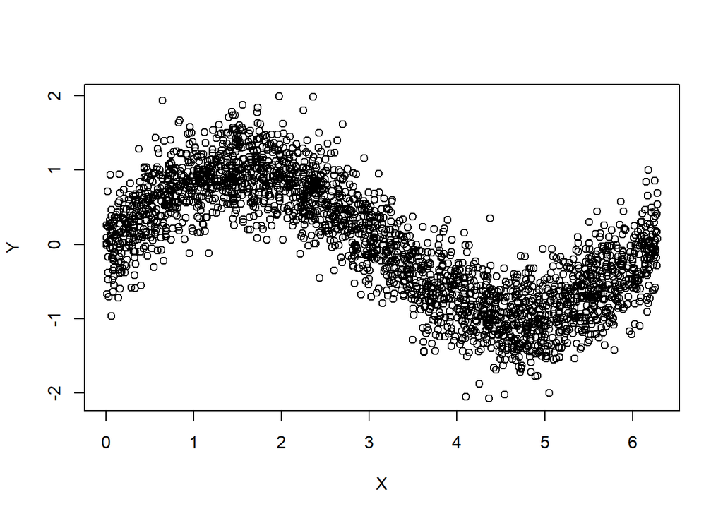

```r
plot(X, Y)
```

```r
knn_func<-function(x, df, k){
  for(i in 1:nrow(df)){
    df[i,3] <- sqrt(((x - df[i,1]))^2)
  }
  ordered_df <- df[order(df[,3]),]
  Yk <-ordered_df[1:k,2]
  return(mean(Yk))
}

pred<-knn_func(1.5, df_points, 2)
pred
```

```
## [1] 1.439555
```

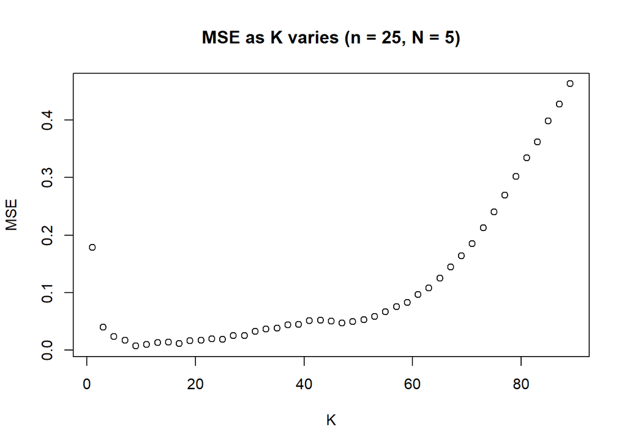

```r
knn_mse<-function(y_hat, y) {
  mean((y_hat - y)^2)
}

knn_var<-function(y_hat, y){
  (y_hat - knn_mean(y))^2
}

knn_bias<-function(y){
  (knn_mean(y) - y)^2
}

knn_mean<-function(x){
  mean(x)
}

get_sim_data = function(sample_size = n) {
  x = runif(n*5, 0, 2*pi)
  y = sin(x) + rnorm(n*5, 0, 0.35)
  data.frame(x, y)
}

x_p = data.frame(x_p = 1)
y_p = sin(1)
predictions = matrix(0, nrow = 5, ncol = k)

for (sim in 1:5) {
  sim_data = get_sim_data(n)
  predictions[sim, 1] = knn_func(x_p, sim_data, 1)
  predictions[sim, 2] = knn_func(x_p, sim_data, 3)
  predictions[sim, 3] = knn_func(x_p, sim_data, 5)
  predictions[sim, 4] = knn_func(x_p, sim_data, 7)
  predictions[sim, 5] = knn_func(x_p, sim_data, 9)
  predictions[sim, 6] = knn_func(x_p, sim_data, 11)
  predictions[sim, 7] = knn_func(x_p, sim_data, 13)
  predictions[sim, 8] = knn_func(x_p, sim_data, 15)
  predictions[sim, 9] = knn_func(x_p, sim_data, 17)
  predictions[sim, 10] = knn_func(x_p, sim_data, 19)
  predictions[sim, 11] = knn_func(x_p, sim_data, 21)
  predictions[sim, 12] = knn_func(x_p, sim_data, 23)
  predictions[sim, 13] = knn_func(x_p, sim_data, 25)
  predictions[sim, 14] = knn_func(x_p, sim_data, 27)
  predictions[sim, 15] = knn_func(x_p, sim_data, 29)
  predictions[sim, 16] = knn_func(x_p, sim_data, 31)
  predictions[sim, 17] = knn_func(x_p, sim_data, 33)
  predictions[sim, 18] = knn_func(x_p, sim_data, 35)
  predictions[sim, 19] = knn_func(x_p, sim_data, 37)
  predictions[sim, 20] = knn_func(x_p, sim_data, 39)
  predictions[sim, 21] = knn_func(x_p, sim_data, 41)
  predictions[sim, 22] = knn_func(x_p, sim_data, 43)
  predictions[sim, 23] = knn_func(x_p, sim_data, 45)
  predictions[sim, 24] = knn_func(x_p, sim_data, 47)
  predictions[sim, 25] = knn_func(x_p, sim_data, 49)
  predictions[sim, 26] = knn_func(x_p, sim_data, 51)
  predictions[sim, 27] = knn_func(x_p, sim_data, 53)
  predictions[sim, 28] = knn_func(x_p, sim_data, 55)
  predictions[sim, 29] = knn_func(x_p, sim_data, 57)
  predictions[sim, 30] = knn_func(x_p, sim_data, 59)
  predictions[sim, 31] = knn_func(x_p, sim_data, 61)
  predictions[sim, 32] = knn_func(x_p, sim_data, 63)
  predictions[sim, 33] = knn_func(x_p, sim_data, 65)
  predictions[sim, 34] = knn_func(x_p, sim_data, 67)
  predictions[sim, 35] = knn_func(x_p, sim_data, 69)
  predictions[sim, 36] = knn_func(x_p, sim_data, 71)
  predictions[sim, 37] = knn_func(x_p, sim_data, 73)
  predictions[sim, 38] = knn_func(x_p, sim_data, 75)
  predictions[sim, 39] = knn_func(x_p, sim_data, 77)
  predictions[sim, 40] = knn_func(x_p, sim_data, 79)
  predictions[sim, 41] = knn_func(x_p, sim_data, 81)
  predictions[sim, 42] = knn_func(x_p, sim_data, 83)
  predictions[sim, 43] = knn_func(x_p, sim_data, 85)
  predictions[sim, 44] = knn_func(x_p, sim_data, 87)
  predictions[sim, 45] = knn_func(x_p, sim_data, 89)
}

# Plot MSE n = 25, N = 5

k_col_m <- seq(1, by = 2, len = k)
k_MSE <- rep(0, k)
mse_set <- data.frame(k_col_m, k_MSE)

for(i in 1:k){
  mse_set[i, 2] <- knn_mse(y_p, predictions[,i])
}

plot(mse_set, xlab = "K", ylab = "MSE", main = "MSE as K varies (n = 25, N = 5)")
```

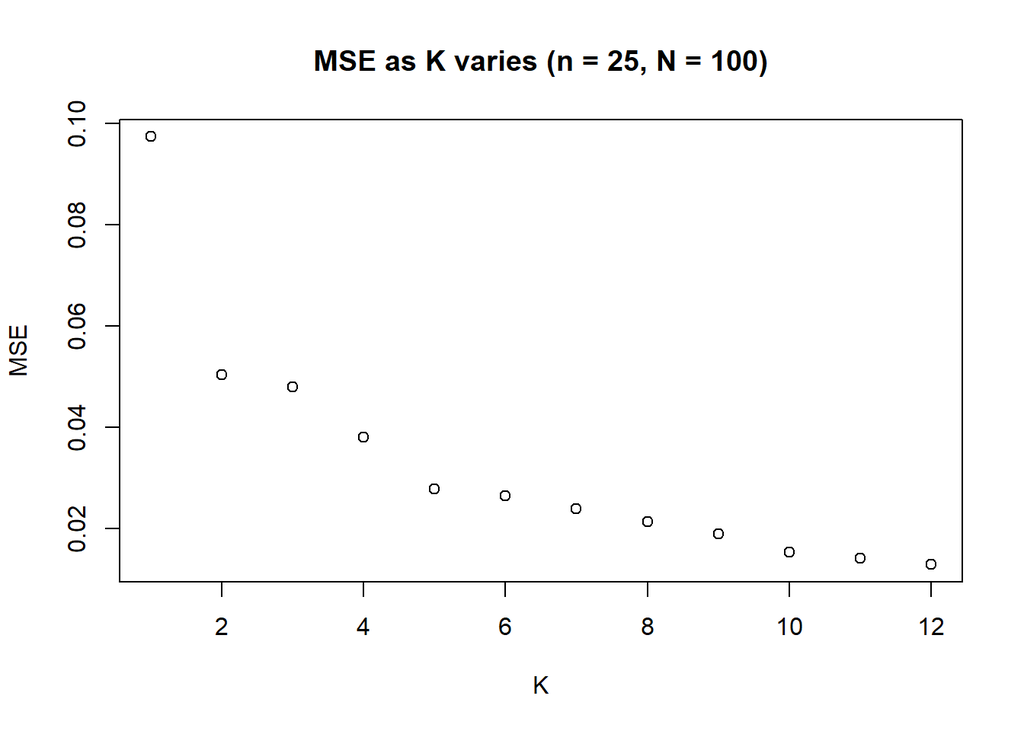

```r
k2 = 12

x_p = data.frame(x_p = 1)
y_p = sin(1)
predictions = matrix(0, nrow = N, ncol = k2)

for (sim in 1:N) {
  sim_data = get_sim_data(n)
  predictions[sim, 1] = knn_func(x_p, sim_data, 1)
  predictions[sim, 2] = knn_func(x_p, sim_data, 2)
  predictions[sim, 3] = knn_func(x_p, sim_data, 3)
  predictions[sim, 4] = knn_func(x_p, sim_data, 4)
  predictions[sim, 5] = knn_func(x_p, sim_data, 5)
  predictions[sim, 6] = knn_func(x_p, sim_data, 6)
  predictions[sim, 7] = knn_func(x_p, sim_data, 7)
  predictions[sim, 8] = knn_func(x_p, sim_data, 8)
  predictions[sim, 9] = knn_func(x_p, sim_data, 9)
  predictions[sim, 10] = knn_func(x_p, sim_data, 10)
  predictions[sim, 11] = knn_func(x_p, sim_data, 11)
  predictions[sim, 12] = knn_func(x_p, sim_data, 12)
}

# Plot MSE n = 25, N = 100

k_col_m <- rep(1:k2)
k_MSE <- rep(0, k2)
mse_set <- data.frame(k_col_m, k_MSE)

for(i in 1:k2){
  mse_set[i, 2] <- knn_mse(y_p, predictions[,i])
}

plot(mse_set, xlab = "K", ylab = "MSE", main = "MSE as K varies (n = 25, N = 100)")
```

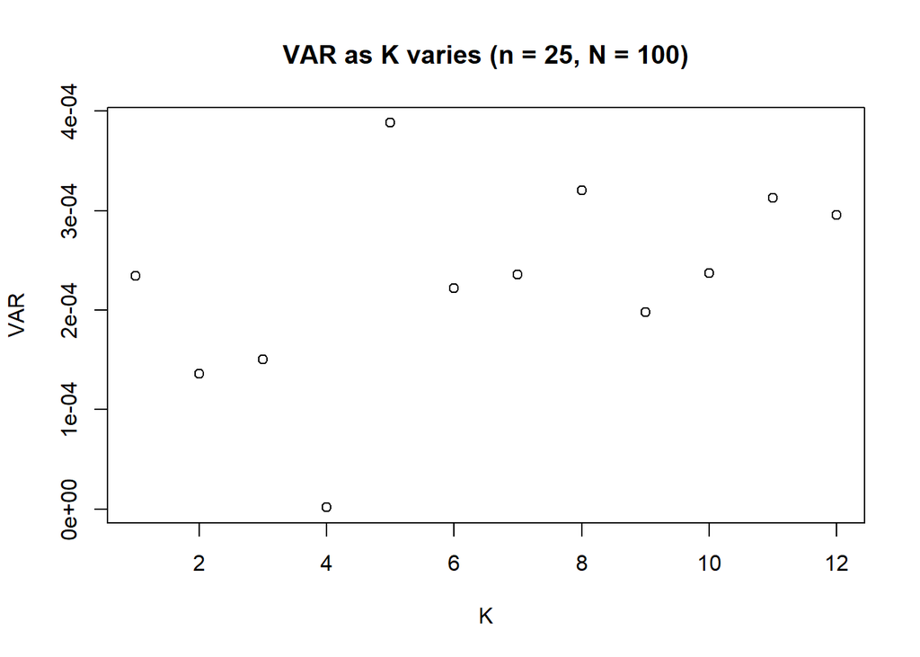

```r
# Plot VAR n = 25, N = 100

k_col_v <- rep(1:k2)
k_VAR <- rep(0, k2)
var_set <- data.frame(k_col_v, k_VAR)

for(i in 1:k2){
  var_set[i, 2] <- knn_var(y_p, predictions[,i])
}

plot(var_set, xlab = "K", ylab = "VAR", main = "VAR as K varies (n = 25, N = 100)")
```

**(2) In the previous question, you should find that the sample MSE is large when k is too small and when k is too big, obtaining a minimum somewhere in the middle. Find the optimal value of k. Also give an informal argument as to why your choices of N, k in the previous question are likely “good enough” to have confidence in your answer**

The first model, I chose $N = 5$ and $n = 25$, meaning the model averages over 5 sample estimates of 25 data points. I fit 45 $k$ values (1 to 89). I was curious to see the behavior when $k$ becomes large when both $N$ and $n$ are relatively small.

For the $k = 12$ model, I chose $N = 100$. As N becomes sufficiently large, it becomes much more accurate even as n varies, based on the unlikeliness of finding 100 estimates from 100 samples that are all very far off from the mean when averaged (given that there is no measurement error and the irreducible errors are normal).

**(3) Repeat the optimization procedure in parts (1,2) of this question, this time with n = 100. Does the value of k change? In what direction does it go? In light of this evidence, predict what would happen if you did the same procedure with n = 10000.**

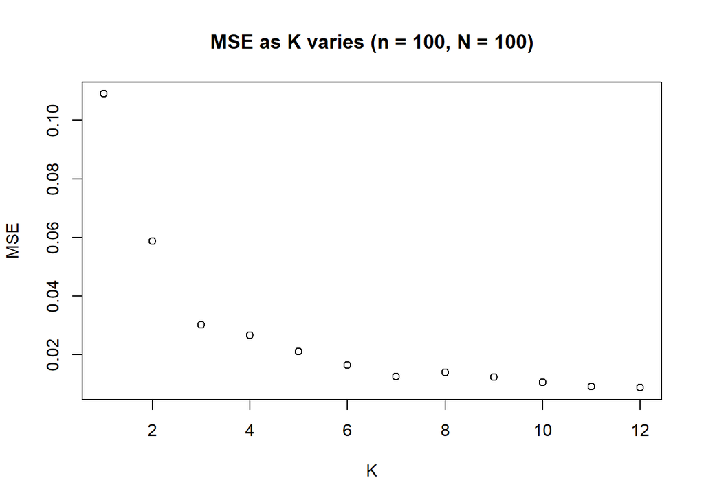

```r
n3 = 100
k3 = 12

x_p = data.frame(x_p = 1)
y_p = sin(1)
predictions = matrix(0, nrow = N, ncol = k3)

for (sim in 1:N) {
  sim_data = get_sim_data(n3)
  predictions[sim, 1] = knn_func(x_p, sim_data, 1)
  predictions[sim, 2] = knn_func(x_p, sim_data, 2)
  predictions[sim, 3] = knn_func(x_p, sim_data, 3)
  predictions[sim, 4] = knn_func(x_p, sim_data, 4)
  predictions[sim, 5] = knn_func(x_p, sim_data, 5)
  predictions[sim, 6] = knn_func(x_p, sim_data, 6)
  predictions[sim, 7] = knn_func(x_p, sim_data, 7)
  predictions[sim, 8] = knn_func(x_p, sim_data, 8)
  predictions[sim, 9] = knn_func(x_p, sim_data, 9)
  predictions[sim, 10] = knn_func(x_p, sim_data, 10)
  predictions[sim, 11] = knn_func(x_p, sim_data, 11)
  predictions[sim, 12] = knn_func(x_p, sim_data, 12)
}

# Plot MSE, n = 100, N = 100

k_col_m <- rep(1:k3)
k_MSE <- rep(0, k3)

mse_set <- data.frame(k_col_m, k_MSE)

for(i in 1:k3){
  mse_set[i, 2] <- knn_mse(y_p, predictions[,i])
}

plot(mse_set, xlab = "K", ylab = "MSE", main = "MSE as K varies (n = 100, N = 100)")
```

### Question 7

**(1) Explore the numerical values in the training dataset using your favourite tools - summary, pairs, hist, or anything else you like. Clean up the data by dealing with NAs and converting non-numerical data to numerical data when appropriate (though see part 4 of this question before doing so). Comment on any relationships and any possibly-bad datapoints**

Load the data, check data set size, view columns.

```r
set.seed(100)

L_data = read.csv("ListingsOptimization.csv")
L_data_train = read.csv("ListingsTrain.csv")
L_data_test = read.csv("ListingsTest.csv")

nrow(L_data)
```

```
## [1] 1000
```

```r
nrow(L_data_train)
```

```
## [1] 1000
```

```r
nrow(L_data_test)
```

```
## [1] 671
```

Function to summarize data: index, column name, data type, NA’s (proper and text) and missing value counts.

```r
L_data_clean<- L_data_train
L_data_clean_test <- L_data_test
L_data_clean_opt <- L_data

summarize<-function(data){
  index = 0
  for(col in colnames(data)){
  index = index + 1
  na <- sum(is.na(data[[col]]))
  text_na <- length(which( data[[col]] == "N/A" ))
  missing <- length(which( data[[col]] == "" ))
  print(paste(index, "NAME:[", col, "] TYPE:[", class(data[[col]]), "] NA:[", na, "] TEXT NA:[", text_na, "] MISSING: [", missing, "]"))
  }
}

summarize(L_data_clean)
```

```
## [1] "1 NAME:[ description ] TYPE:[ character ] NA:[ 0 ] TEXT NA:[ 0 ] MISSING: [ 1 ]"
## [1] "2 NAME:[ neighborhood_overview ] TYPE:[ character ] NA:[ 0 ] TEXT NA:[ 0 ] MISSING: [ 243 ]"
## [1] "3 NAME:[ host_response_time ] TYPE:[ character ] NA:[ 0 ] TEXT NA:[ 406 ] MISSING: [ 0 ]"
## [1] "4 NAME:[ host_response_rate ] TYPE:[ character ] NA:[ 0 ] TEXT NA:[ 406 ] MISSING: [ 0 ]"
## [1] "5 NAME:[ host_acceptance_rate ] TYPE:[ character ] NA:[ 0 ] TEXT NA:[ 262 ] MISSING: [ 0 ]"
## [1] "6 NAME:[ host_is_superhost ] TYPE:[ character ] NA:[ 0 ] TEXT NA:[ 0 ] MISSING: [ 0 ]"
## [1] "7 NAME:[ host_neighbourhood ] TYPE:[ character ] NA:[ 0 ] TEXT NA:[ 0 ] MISSING: [ 898 ]"
## [1] "8 NAME:[ host_listings_count ] TYPE:[ integer ] NA:[ 0 ] TEXT NA:[ 0 ] MISSING: [ 0 ]"
## [1] "9 NAME:[ host_total_listings_count ] TYPE:[ integer ] NA:[ 0 ] TEXT NA:[ 0 ] MISSING: [ 0 ]"
## [1] "10 NAME:[ host_has_profile_pic ] TYPE:[ character ] NA:[ 0 ] TEXT NA:[ 0 ] MISSING: [ 0 ]"
## [1] "11 NAME:[ host_identity_verified ] TYPE:[ character ] NA:[ 0 ] TEXT NA:[ 0 ] MISSING: [ 0 ]"
## [1] "12 NAME:[ neighbourhood_cleansed ] TYPE:[ character ] NA:[ 0 ] TEXT NA:[ 0 ] MISSING: [ 0 ]"
## [1] "13 NAME:[ neighbourhood_group_cleansed ] TYPE:[ logical ] NA:[ 1000 ] TEXT NA:[ 0 ] MISSING: [ 0 ]"
## [1] "14 NAME:[ latitude ] TYPE:[ numeric ] NA:[ 0 ] TEXT NA:[ 0 ] MISSING: [ 0 ]"
## [1] "15 NAME:[ longitude ] TYPE:[ numeric ] NA:[ 0 ] TEXT NA:[ 0 ] MISSING: [ 0 ]"
```

[output cut: 28 more lines]

Clean data section by section.

```r
L_data_clean[1:5, 3:6]
```

```
##   host_response_time host_response_rate host_acceptance_rate host_is_superhost
## 1     within an hour               100%                  94%                 f
## 2     within an hour               100%                  50%                 t
## 3     within an hour               100%                  92%                 t
## 4 within a few hours               100%                 100%                 f
## 5                N/A                N/A                  N/A                 f
```

```r
summarize(L_data_clean[, 3:6])
```

```
## [1] "1 NAME:[ host_response_time ] TYPE:[ character ] NA:[ 0 ] TEXT NA:[ 406 ] MISSING: [ 0 ]"
## [1] "2 NAME:[ host_response_rate ] TYPE:[ character ] NA:[ 0 ] TEXT NA:[ 406 ] MISSING: [ 0 ]"
## [1] "3 NAME:[ host_acceptance_rate ] TYPE:[ character ] NA:[ 0 ] TEXT NA:[ 262 ] MISSING: [ 0 ]"
## [1] "4 NAME:[ host_is_superhost ] TYPE:[ character ] NA:[ 0 ] TEXT NA:[ 0 ] MISSING: [ 0 ]"
```

```r
unique(L_data_clean$host_response_time, incomparables = FALSE)
```

```
## [1] "within an hour"     "within a few hours" "N/A"
## [4] "within a day"       "a few days or more"
```

```r
unique(L_data_clean$host_response_time, incomparables = FALSE)
```

```
## [1] "within an hour"     "within a few hours" "N/A"
## [4] "within a day"       "a few days or more"
```

```r
# Convert percentages to numeric

L_data_clean$host_response_rate <- str_replace(L_data_clean$host_response_rate, "[%]", "")
L_data_clean$host_response_rate <- as.numeric(L_data_clean$host_response_rate)/100
L_data_clean$host_acceptance_rate <- str_replace(L_data_clean$host_acceptance_rate, "[%]", "")
L_data_clean$host_acceptance_rate <- as.numeric(L_data_clean$host_acceptance_rate)/100
L_data_clean_test$host_response_rate <- str_replace(L_data_clean_test$host_response_rate, "[%]", "")
L_data_clean_test$host_response_rate <- as.numeric(L_data_clean_test$host_response_rate)/100
L_data_clean_test$host_acceptance_rate <- str_replace(L_data_clean_test$host_acceptance_rate, "[%]", "")
L_data_clean_test$host_acceptance_rate <- as.numeric(L_data_clean_test$host_acceptance_rate)/100
L_data_clean_opt$host_response_rate <- str_replace(L_data_clean$host_response_rate, "[%]", "")
L_data_clean_opt$host_response_rate <- as.numeric(L_data_clean$host_response_rate)/100

L_data_clean_opt$host_acceptance_rate <- str_replace(L_data_clean_opt$host_acceptance_rate, "[%]", "")
L_data_clean_opt$host_acceptance_rate <- as.numeric(L_data_clean_opt$host_acceptance_rate)/100
# Convert text NA's and missing values to NA

L_data_clean$host_response_time <- ifelse(L_data_clean$host_response_time == "N/A", NA, ifelse(L_data_clean$host_response_time == "", NA, L_data_clean$host_response_time))

L_data_clean_test$host_response_time <- ifelse(L_data_clean_test$host_response_time == "N/A", NA, ifelse(L_data_clean_test$host_response_time == "", NA, L_data_clean_test$host_response_time))

L_data_clean_opt$host_response_time <- ifelse(L_data_clean_opt$host_response_time == "N/A", NA, ifelse(L_data_clean_opt$host_response_time == "", NA, L_data_clean_opt$host_response_time))

# Convert character t/f to numeric 1/0

L_data_clean$host_is_superhost <- ifelse(L_data_clean$host_is_superhost == "f", 1, 0)
L_data_clean_test$host_is_superhost <- ifelse(L_data_clean_test$host_is_superhost == "f", 1, 0)
L_data_clean_opt$host_is_superhost <- ifelse(L_data_clean_opt$host_is_superhost == "f", 1, 0)


# Check finished section

L_data_clean[1:5, 3:6]
```

```
##   host_response_time host_response_rate host_acceptance_rate host_is_superhost
## 1     within an hour                  1                 0.94                 1
## 2     within an hour                  1                 0.50                 0
## 3     within an hour                  1                 0.92                 0
## 4 within a few hours                  1                 1.00                 1
## 5               <NA>                 NA                   NA                 1
```

```r
summarize(L_data_clean[,3:6])
```

```
## [1] "1 NAME:[ host_response_time ] TYPE:[ character ] NA:[ 406 ] TEXT NA:[ 0 ] MISSING: [ 0 ]"
## [1] "2 NAME:[ host_response_rate ] TYPE:[ numeric ] NA:[ 406 ] TEXT NA:[ 0 ] MISSING: [ 0 ]"
## [1] "3 NAME:[ host_acceptance_rate ] TYPE:[ numeric ] NA:[ 262 ] TEXT NA:[ 0 ] MISSING: [ 0 ]"
## [1] "4 NAME:[ host_is_superhost ] TYPE:[ numeric ] NA:[ 0 ] TEXT NA:[ 0 ] MISSING: [ 0 ]"
```

```r
#-------- Clean next section

L_data_clean[1:5, 7:21]
```

```
##                host_neighbourhood host_listings_count host_total_listings_count
## 1                                                   5                         5
## 2                      Lower Town                   4                         4
## 3 Byward Market - Parliament Hill                   3                         3
## 4                                                   1                         1
## 5                                                   0                         0
##   host_has_profile_pic host_identity_verified neighbourhood_cleansed
## 1                    t                      t                  Innes
## 2                    t                      t          Rideau-Vanier
## 3                    t                      t          Rideau-Vanier
## 4                    t                      t       Rideau-Goulbourn
## 5                    t                      t                College
##   neighbourhood_group_cleansed latitude longitude         property_type
## 1                           NA 45.43155 -75.56861      Entire apartment
## 2                           NA 45.43479 -75.68787      Entire apartment
## 3                           NA 45.42986 -75.69486      Entire apartment
## 4                           NA 45.22002 -75.67427       Entire bungalow
## 5                           NA 45.35638 -75.76115 Private room in house
##         room_type accommodates bathrooms bedrooms beds
## 1 Entire home/apt            4        NA        1    2
## 2 Entire home/apt            2        NA        1    1
## 3 Entire home/apt            7        NA        3    3
## 4 Entire home/apt            8        NA        4    4
## 5    Private room            3        NA        1    2
```

```r
summarize(L_data_clean[,7:21])
```

```
## [1] "1 NAME:[ host_neighbourhood ] TYPE:[ character ] NA:[ 0 ] TEXT NA:[ 0 ] MISSING: [ 898 ]"
## [1] "2 NAME:[ host_listings_count ] TYPE:[ integer ] NA:[ 0 ] TEXT NA:[ 0 ] MISSING: [ 0 ]"
## [1] "3 NAME:[ host_total_listings_count ] TYPE:[ integer ] NA:[ 0 ] TEXT NA:[ 0 ] MISSING: [ 0 ]"
## [1] "4 NAME:[ host_has_profile_pic ] TYPE:[ character ] NA:[ 0 ] TEXT NA:[ 0 ] MISSING: [ 0 ]"
## [1] "5 NAME:[ host_identity_verified ] TYPE:[ character ] NA:[ 0 ] TEXT NA:[ 0 ] MISSING: [ 0 ]"
## [1] "6 NAME:[ neighbourhood_cleansed ] TYPE:[ character ] NA:[ 0 ] TEXT NA:[ 0 ] MISSING: [ 0 ]"
## [1] "7 NAME:[ neighbourhood_group_cleansed ] TYPE:[ logical ] NA:[ 1000 ] TEXT NA:[ 0 ] MISSING: [ 0 ]"
## [1] "8 NAME:[ latitude ] TYPE:[ numeric ] NA:[ 0 ] TEXT NA:[ 0 ] MISSING: [ 0 ]"
## [1] "9 NAME:[ longitude ] TYPE:[ numeric ] NA:[ 0 ] TEXT NA:[ 0 ] MISSING: [ 0 ]"
## [1] "10 NAME:[ property_type ] TYPE:[ character ] NA:[ 0 ] TEXT NA:[ 0 ] MISSING: [ 0 ]"
## [1] "11 NAME:[ room_type ] TYPE:[ character ] NA:[ 0 ] TEXT NA:[ 0 ] MISSING: [ 0 ]"
## [1] "12 NAME:[ accommodates ] TYPE:[ integer ] NA:[ 0 ] TEXT NA:[ 0 ] MISSING: [ 0 ]"
## [1] "13 NAME:[ bathrooms ] TYPE:[ logical ] NA:[ 1000 ] TEXT NA:[ 0 ] MISSING: [ 0 ]"
## [1] "14 NAME:[ bedrooms ] TYPE:[ integer ] NA:[ 58 ] TEXT NA:[ 0 ] MISSING: [ 0 ]"
## [1] "15 NAME:[ beds ] TYPE:[ integer ] NA:[ 0 ] TEXT NA:[ 0 ] MISSING: [ 0 ]"
```

```r
# Convert character t/f to numeric 1/0

L_data_clean$host_has_profile_pic <- ifelse(L_data_clean$host_has_profile_pic == "f", 1, 0)
L_data_clean$host_identity_verified <- ifelse(L_data_clean$host_identity_verified == "f", 1, 0)

L_data_clean_test$host_has_profile_pic <- ifelse(L_data_clean_test$host_has_profile_pic == "f", 1, 0)
L_data_clean_test$host_identity_verified <- ifelse(L_data_clean_test$host_identity_verified == "f", 1, 0)

L_data_clean_opt$host_has_profile_pic <- ifelse(L_data_clean_opt$host_has_profile_pic == "f", 1, 0)
L_data_clean_opt$host_identity_verified <- ifelse(L_data_clean_opt$host_identity_verified == "f", 1, 0)

# Drop 'bathrooms' and 'neighbourhood_group_cleansed' columns due to 100% NA, 'host_neighbourhood' due to majority missing

L_data_clean = subset(L_data_clean, select = -c(host_neighbourhood, bathrooms, neighbourhood_group_cleansed) )

L_data_clean_test = subset(L_data_clean_test, select = -c(host_neighbourhood, bathrooms, neighbourhood_group_cleansed) )

L_data_clean_opt = subset(L_data_clean_opt, select = -c(host_neighbourhood, bathrooms, neighbourhood_group_cleansed) )

# Check finished section

L_data_clean[1:5, 7:18]
```

```
##   host_listings_count host_total_listings_count host_has_profile_pic
## 1                   5                         5                    0
## 2                   4                         4                    0
## 3                   3                         3                    0
## 4                   1                         1                    0
## 5                   0                         0                    0
##   host_identity_verified neighbourhood_cleansed latitude longitude
## 1                      0                  Innes 45.43155 -75.56861
## 2                      0          Rideau-Vanier 45.43479 -75.68787
## 3                      0          Rideau-Vanier 45.42986 -75.69486
## 4                      0       Rideau-Goulbourn 45.22002 -75.67427
## 5                      0                College 45.35638 -75.76115
##           property_type       room_type accommodates bedrooms beds
## 1      Entire apartment Entire home/apt            4        1    2
## 2      Entire apartment Entire home/apt            2        1    1
## 3      Entire apartment Entire home/apt            7        3    3
## 4       Entire bungalow Entire home/apt            8        4    4
## 5 Private room in house    Private room            3        1    2
```

```r
summarize(L_data_clean[,7:18])
```

```
## [1] "1 NAME:[ host_listings_count ] TYPE:[ integer ] NA:[ 0 ] TEXT NA:[ 0 ] MISSING: [ 0 ]"
## [1] "2 NAME:[ host_total_listings_count ] TYPE:[ integer ] NA:[ 0 ] TEXT NA:[ 0 ] MISSING: [ 0 ]"
## [1] "3 NAME:[ host_has_profile_pic ] TYPE:[ numeric ] NA:[ 0 ] TEXT NA:[ 0 ] MISSING: [ 0 ]"
## [1] "4 NAME:[ host_identity_verified ] TYPE:[ numeric ] NA:[ 0 ] TEXT NA:[ 0 ] MISSING: [ 0 ]"
## [1] "5 NAME:[ neighbourhood_cleansed ] TYPE:[ character ] NA:[ 0 ] TEXT NA:[ 0 ] MISSING: [ 0 ]"
## [1] "6 NAME:[ latitude ] TYPE:[ numeric ] NA:[ 0 ] TEXT NA:[ 0 ] MISSING: [ 0 ]"
## [1] "7 NAME:[ longitude ] TYPE:[ numeric ] NA:[ 0 ] TEXT NA:[ 0 ] MISSING: [ 0 ]"
## [1] "8 NAME:[ property_type ] TYPE:[ character ] NA:[ 0 ] TEXT NA:[ 0 ] MISSING: [ 0 ]"
## [1] "9 NAME:[ room_type ] TYPE:[ character ] NA:[ 0 ] TEXT NA:[ 0 ] MISSING: [ 0 ]"
## [1] "10 NAME:[ accommodates ] TYPE:[ integer ] NA:[ 0 ] TEXT NA:[ 0 ] MISSING: [ 0 ]"
## [1] "11 NAME:[ bedrooms ] TYPE:[ integer ] NA:[ 58 ] TEXT NA:[ 0 ] MISSING: [ 0 ]"
## [1] "12 NAME:[ beds ] TYPE:[ integer ] NA:[ 0 ] TEXT NA:[ 0 ] MISSING: [ 0 ]"
```

```r
#-------- Clean next section

L_data_clean[1:5, 20:26]
```

```
##     price minimum_nights maximum_nights has_availability number_of_reviews
## 1 $109.00              5           1125                t                14
## 2  $96.00              5            365                t                 2
## 3 $158.00              1            360                t               151
## 4 $186.00              3           1125                t               111
## 5  $70.00              2             20                t                 3
##   number_of_reviews_ltm number_of_reviews_l30d
## 1                     0                      0
## 2                     0                      0
## 3                    12                      0
## 4                     6                      0
## 5                     0                      0
```

```r
summarize(L_data_clean[,20:26])
```

```
## [1] "1 NAME:[ price ] TYPE:[ character ] NA:[ 0 ] TEXT NA:[ 0 ] MISSING: [ 0 ]"
## [1] "2 NAME:[ minimum_nights ] TYPE:[ integer ] NA:[ 0 ] TEXT NA:[ 0 ] MISSING: [ 0 ]"
## [1] "3 NAME:[ maximum_nights ] TYPE:[ integer ] NA:[ 0 ] TEXT NA:[ 0 ] MISSING: [ 0 ]"
## [1] "4 NAME:[ has_availability ] TYPE:[ character ] NA:[ 0 ] TEXT NA:[ 0 ] MISSING: [ 0 ]"
## [1] "5 NAME:[ number_of_reviews ] TYPE:[ integer ] NA:[ 0 ] TEXT NA:[ 0 ] MISSING: [ 0 ]"
## [1] "6 NAME:[ number_of_reviews_ltm ] TYPE:[ integer ] NA:[ 0 ] TEXT NA:[ 0 ] MISSING: [ 0 ]"
## [1] "7 NAME:[ number_of_reviews_l30d ] TYPE:[ integer ] NA:[ 0 ] TEXT NA:[ 0 ] MISSING: [ 0 ]"
```

```r
# Convert character t/f to numeric 1/0

L_data_clean$has_availability <- ifelse(L_data_clean$has_availability == "f", 1, 0)
L_data_clean_test$has_availability <- ifelse(L_data_clean_test$has_availability == "f", 1, 0)
L_data_clean_opt$has_availability <- ifelse(L_data_clean_opt$has_availability == "f", 1, 0)

# Convert price to numeric

L_data_clean$price <- str_replace(L_data_clean$price, "[$]", "")
L_data_clean$price <- as.numeric(L_data_clean$price)
L_data_clean_test$price <- str_replace(L_data_clean_test$price, "[$]", "")
L_data_clean_test$price <- as.numeric(L_data_clean_test$price)
L_data_clean_opt$price <- str_replace(L_data_clean_opt$price, "[$]", "")
L_data_clean_opt$price <- as.numeric(L_data_clean_opt$price)
# Check finished section

L_data_clean[1:5, 20:26]
```

```
##   price minimum_nights maximum_nights has_availability number_of_reviews
## 1   109              5           1125                0                14
## 2    96              5            365                0                 2
## 3   158              1            360                0               151
## 4   186              3           1125                0               111
## 5    70              2             20                0                 3
##   number_of_reviews_ltm number_of_reviews_l30d
## 1                     0                      0
## 2                     0                      0
## 3                    12                      0
## 4                     6                      0
## 5                     0                      0
```

```r
summarize(L_data_clean[,20:26])
```

```
## [1] "1 NAME:[ price ] TYPE:[ numeric ] NA:[ 4 ] TEXT NA:[ 0 ] MISSING: [ 0 ]"
## [1] "2 NAME:[ minimum_nights ] TYPE:[ integer ] NA:[ 0 ] TEXT NA:[ 0 ] MISSING: [ 0 ]"
## [1] "3 NAME:[ maximum_nights ] TYPE:[ integer ] NA:[ 0 ] TEXT NA:[ 0 ] MISSING: [ 0 ]"
## [1] "4 NAME:[ has_availability ] TYPE:[ numeric ] NA:[ 0 ] TEXT NA:[ 0 ] MISSING: [ 0 ]"
## [1] "5 NAME:[ number_of_reviews ] TYPE:[ integer ] NA:[ 0 ] TEXT NA:[ 0 ] MISSING: [ 0 ]"
## [1] "6 NAME:[ number_of_reviews_ltm ] TYPE:[ integer ] NA:[ 0 ] TEXT NA:[ 0 ] MISSING: [ 0 ]"
## [1] "7 NAME:[ number_of_reviews_l30d ] TYPE:[ integer ] NA:[ 0 ] TEXT NA:[ 0 ] MISSING: [ 0 ]"
```

```r
#-------- Clean next section

L_data_clean[1:5, 27:40]
```

```
##   first_review last_review review_scores_rating review_scores_accuracy
## 1   2017-06-04  2019-02-19                   98                     10
## 2   2019-05-02  2019-06-07                  100                     10
## 3   2016-12-31  2020-09-06                   94                     10
## 4   2017-05-21  2020-10-21                   97                     10
## 5   2017-05-22  2018-08-06                   80                     10
##   review_scores_cleanliness review_scores_checkin review_scores_communication
## 1                        10                    10                          10
## 2                        10                    10                          10
## 3                        10                    10                          10
## 4                         9                    10                          10
## 5                        10                    10                           9
##   review_scores_location review_scores_value instant_bookable
## 1                      9                  10                t
## 2                     10                  10                f
## 3                     10                   9                f
## 4                     10                  10                f
## 5                      9                   9                t
##   calculated_host_listings_count calculated_host_listings_count_entire_homes
## 1                              5                                           5
## 2                              5                                           5
## 3                              4                                           4
## 4                              1                                           1
## 5                              1                                           0
##   calculated_host_listings_count_private_rooms reviews_per_month
## 1                                            0              0.31
## 2                                            0              0.09
## 3                                            0              3.01
## 4                                            0              2.44
## 5                                            1              0.07
```

```r
summarize(L_data_clean[,27:40])
```

```
## [1] "1 NAME:[ first_review ] TYPE:[ character ] NA:[ 0 ] TEXT NA:[ 0 ] MISSING: [ 56 ]"
## [1] "2 NAME:[ last_review ] TYPE:[ character ] NA:[ 0 ] TEXT NA:[ 0 ] MISSING: [ 56 ]"
## [1] "3 NAME:[ review_scores_rating ] TYPE:[ integer ] NA:[ 69 ] TEXT NA:[ 0 ] MISSING: [ 0 ]"
## [1] "4 NAME:[ review_scores_accuracy ] TYPE:[ integer ] NA:[ 71 ] TEXT NA:[ 0 ] MISSING: [ 0 ]"
## [1] "5 NAME:[ review_scores_cleanliness ] TYPE:[ integer ] NA:[ 70 ] TEXT NA:[ 0 ] MISSING: [ 0 ]"
## [1] "6 NAME:[ review_scores_checkin ] TYPE:[ integer ] NA:[ 72 ] TEXT NA:[ 0 ] MISSING: [ 0 ]"
## [1] "7 NAME:[ review_scores_communication ] TYPE:[ integer ] NA:[ 72 ] TEXT NA:[ 0 ] MISSING: [ 0 ]"
## [1] "8 NAME:[ review_scores_location ] TYPE:[ integer ] NA:[ 72 ] TEXT NA:[ 0 ] MISSING: [ 0 ]"
## [1] "9 NAME:[ review_scores_value ] TYPE:[ integer ] NA:[ 72 ] TEXT NA:[ 0 ] MISSING: [ 0 ]"
## [1] "10 NAME:[ instant_bookable ] TYPE:[ character ] NA:[ 0 ] TEXT NA:[ 0 ] MISSING: [ 0 ]"
## [1] "11 NAME:[ calculated_host_listings_count ] TYPE:[ integer ] NA:[ 0 ] TEXT NA:[ 0 ] MISSING: [ 0 ]"
## [1] "12 NAME:[ calculated_host_listings_count_entire_homes ] TYPE:[ integer ] NA:[ 0 ] TEXT NA:[ 0 ] MISSING: [ 0 ]"
## [1] "13 NAME:[ calculated_host_listings_count_private_rooms ] TYPE:[ integer ] NA:[ 0 ] TEXT NA:[ 0 ] MISSING: [ 0 ]"
## [1] "14 NAME:[ reviews_per_month ] TYPE:[ numeric ] NA:[ 56 ] TEXT NA:[ 0 ] MISSING: [ 0 ]"
```

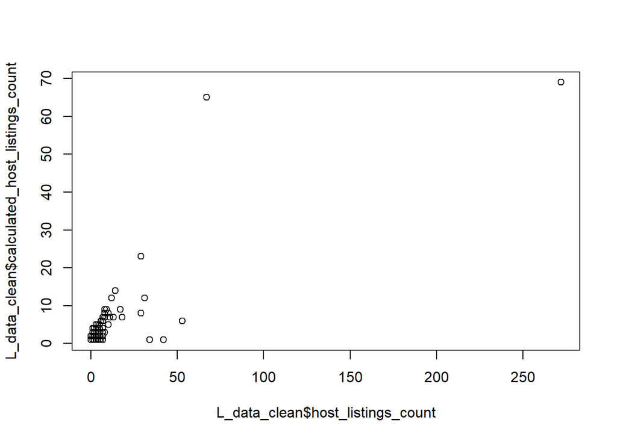

```r
# convert missing date/description values to NA

L_data_clean$first_review <- ifelse(L_data_clean$first_review == "", NA, L_data_clean$first_review)
L_data_clean$last_review <- ifelse(L_data_clean$last_review == "", NA, L_data_clean$last_review)
L_data_clean$description <- ifelse(L_data_clean$description == "", NA, L_data_clean$description)
L_data_clean$neighborhood_overview <- ifelse(L_data_clean$neighborhood_overview == "", NA, L_data_clean$neighborhood_overview)

L_data_clean_test$first_review <- ifelse(L_data_clean_test$first_review == "", NA, L_data_clean_test$first_review)
L_data_clean_test$last_review <- ifelse(L_data_clean_test$last_review == "", NA, L_data_clean_test$last_review)
L_data_clean_test$description <- ifelse(L_data_clean_test$description == "", NA, L_data_clean_test$description)
L_data_clean_test$neighborhood_overview <- ifelse(L_data_clean_test$neighborhood_overview == "", NA, L_data_clean_test$neighborhood_overview)

L_data_clean_opt$first_review <- ifelse(L_data_clean_opt$first_review == "", NA, L_data_clean_opt$first_review)
L_data_clean_opt$last_review <- ifelse(L_data_clean_opt$last_review == "", NA, L_data_clean_opt$last_review)
L_data_clean_opt$description <- ifelse(L_data_clean_opt$description == "", NA, L_data_clean_opt$description)
L_data_clean_opt$neighborhood_overview <- ifelse(L_data_clean_opt$neighborhood_overview == "", NA, L_data_clean_opt$neighborhood_overview)

# Convert character t/f to numeric 1/0

L_data_clean$instant_bookable <- ifelse(L_data_clean$instant_bookable == "f", 1, 0)

L_data_clean_test$instant_bookable <- ifelse(L_data_clean_test$instant_bookable == "f", 1, 0)

L_data_clean_opt$instant_bookable <- ifelse(L_data_clean_opt$instant_bookable == "f", 1, 0)

# Explore relationship between listing count variables

plot(L_data_clean$host_listings_count, L_data_clean$calculated_host_listings_count)
```

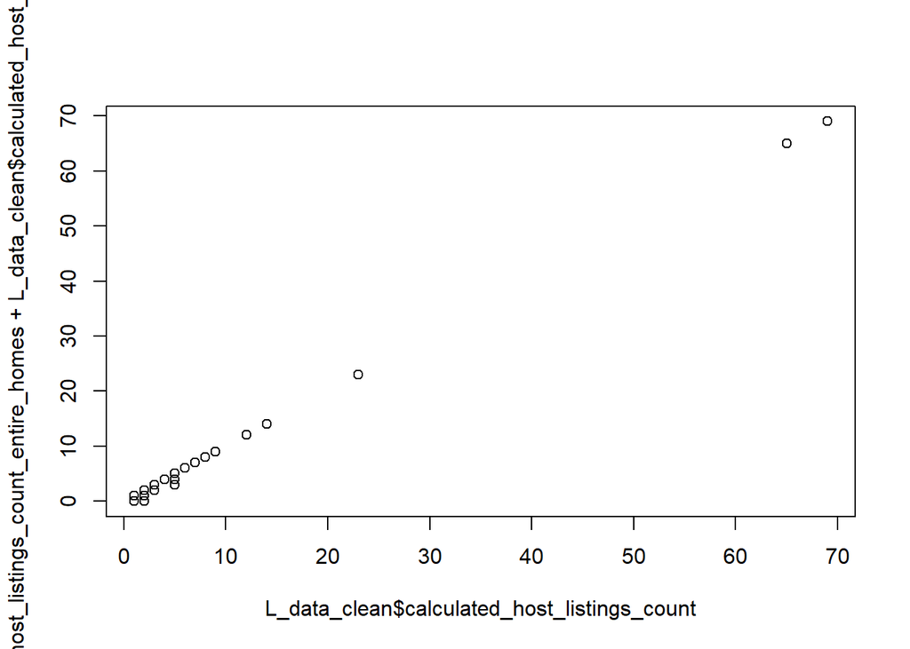

```r
plot(L_data_clean$calculated_host_listings_count, L_data_clean$calculated_host_listings_count_entire_homes + L_data_clean$calculated_host_listings_count_private_rooms)
```

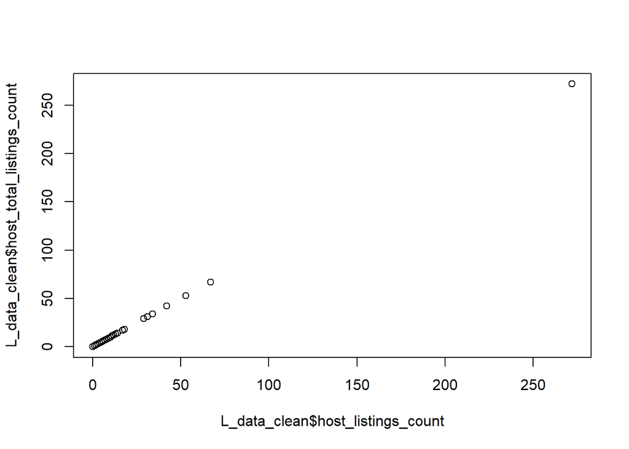

```r
plot(L_data_clean$host_listings_count, L_data_clean$host_total_listings_count)
```

```r
# remove redundant host_total_listings_count

L_data_clean = subset(L_data_clean, select = -c(host_total_listings_count) )

L_data_clean_test = subset(L_data_clean_test, select = -c(host_total_listings_count) )

L_data_clean_opt = subset(L_data_clean_opt, select = -c(host_total_listings_count) )

# check unique values for some categorical variables (error check, cardinality check)

unique(L_data_clean$neighbourhood_cleansed, incomparables = FALSE)
```

```
##  [1] "Innes"                   "Rideau-Vanier"
##  [3] "Rideau-Goulbourn"        "College"
##  [5] "Kitchissippi"            "Gloucester-South Nepean"
##  [7] "Knoxdale-Merivale"       "Capital"
##  [9] "Bay"                     "River"
## [11] "Somerset"                "Rideau-Rockcliffe"
## [13] "Beacon Hill-Cyrville"    "Gloucester-Southgate"
## [15] "Kanata North"            "Osgoode"
## [17] "Kanata South"            "Orleans"
## [19] "Stittsville-Kanata West" "Alta Vista"
## [21] "Barrhaven"               "Cumberland"
## [23] "West Carleton-March"
```

```r
unique(L_data_clean$room_type, incomparables = FALSE)
```

```
## [1] "Entire home/apt" "Private room"    "Shared room"     "Hotel room"
```

```r
unique(L_data_clean$property_type, incomparables = FALSE)
```

```
##  [1] "Entire apartment"                  "Entire bungalow"
##  [3] "Private room in house"             "Private room in bungalow"
##  [5] "Entire house"                      "Camper/RV"
##  [7] "Private room in apartment"         "Private room in condominium"
##  [9] "Private room in townhouse"         "Entire condominium"
## [11] "Entire loft"                       "Entire guest suite"
## [13] "Entire guesthouse"                 "Entire townhouse"
## [15] "Entire serviced apartment"         "Shared room in house"
## [17] "Private room in bed and breakfast" "Entire chalet"
## [19] "Private room in floor"             "Entire cabin"
## [21] "Private room in guest suite"       "Room in bed and breakfast"
## [23] "Entire bed and breakfast"          "Shared room in villa"
## [25] "Tiny house"                        "Entire villa"
## [27] "Shared room in townhouse"          "Private room in guesthouse"
## [29] "Private room in cabin"             "Entire cottage"
## [31] "Shared room in cave"               "Shared room in apartment"
## [33] "Private room"                      "Private room in loft"
## [35] "Private room in farm stay"         "Private room in villa"
## [37] "Yurt"
```

```r
# Check finished section

L_data_clean[1:5, 27:39]
```

```
##   last_review review_scores_rating review_scores_accuracy
## 1  2019-02-19                   98                     10
## 2  2019-06-07                  100                     10
## 3  2020-09-06                   94                     10
## 4  2020-10-21                   97                     10
## 5  2018-08-06                   80                     10
##   review_scores_cleanliness review_scores_checkin review_scores_communication
## 1                        10                    10                          10
## 2                        10                    10                          10
## 3                        10                    10                          10
## 4                         9                    10                          10
## 5                        10                    10                           9
##   review_scores_location review_scores_value instant_bookable
## 1                      9                  10                0
## 2                     10                  10                1
## 3                     10                   9                1
## 4                     10                  10                1
## 5                      9                   9                0
##   calculated_host_listings_count calculated_host_listings_count_entire_homes
## 1                              5                                           5
## 2                              5                                           5
## 3                              4                                           4
## 4                              1                                           1
## 5                              1                                           0
##   calculated_host_listings_count_private_rooms reviews_per_month
## 1                                            0              0.31
## 2                                            0              0.09
## 3                                            0              3.01
## 4                                            0              2.44
## 5                                            1              0.07
```

```r
summarize(L_data_clean[,27:39])
```

```
## [1] "1 NAME:[ last_review ] TYPE:[ character ] NA:[ 56 ] TEXT NA:[ 0 ] MISSING: [ 0 ]"
## [1] "2 NAME:[ review_scores_rating ] TYPE:[ integer ] NA:[ 69 ] TEXT NA:[ 0 ] MISSING: [ 0 ]"
## [1] "3 NAME:[ review_scores_accuracy ] TYPE:[ integer ] NA:[ 71 ] TEXT NA:[ 0 ] MISSING: [ 0 ]"
## [1] "4 NAME:[ review_scores_cleanliness ] TYPE:[ integer ] NA:[ 70 ] TEXT NA:[ 0 ] MISSING: [ 0 ]"
## [1] "5 NAME:[ review_scores_checkin ] TYPE:[ integer ] NA:[ 72 ] TEXT NA:[ 0 ] MISSING: [ 0 ]"
## [1] "6 NAME:[ review_scores_communication ] TYPE:[ integer ] NA:[ 72 ] TEXT NA:[ 0 ] MISSING: [ 0 ]"
## [1] "7 NAME:[ review_scores_location ] TYPE:[ integer ] NA:[ 72 ] TEXT NA:[ 0 ] MISSING: [ 0 ]"
## [1] "8 NAME:[ review_scores_value ] TYPE:[ integer ] NA:[ 72 ] TEXT NA:[ 0 ] MISSING: [ 0 ]"
## [1] "9 NAME:[ instant_bookable ] TYPE:[ numeric ] NA:[ 0 ] TEXT NA:[ 0 ] MISSING: [ 0 ]"
## [1] "10 NAME:[ calculated_host_listings_count ] TYPE:[ integer ] NA:[ 0 ] TEXT NA:[ 0 ] MISSING: [ 0 ]"
## [1] "11 NAME:[ calculated_host_listings_count_entire_homes ] TYPE:[ integer ] NA:[ 0 ] TEXT NA:[ 0 ] MISSING: [ 0 ]"
## [1] "12 NAME:[ calculated_host_listings_count_private_rooms ] TYPE:[ integer ] NA:[ 0 ] TEXT NA:[ 0 ] MISSING: [ 0 ]"
## [1] "13 NAME:[ reviews_per_month ] TYPE:[ numeric ] NA:[ 56 ] TEXT NA:[ 0 ] MISSING: [ 0 ]"
```

```r
#------- Check full cleaned data set

summarize(L_data_clean)
```

```
## [1] "1 NAME:[ description ] TYPE:[ character ] NA:[ 1 ] TEXT NA:[ 0 ] MISSING: [ 0 ]"
## [1] "2 NAME:[ neighborhood_overview ] TYPE:[ character ] NA:[ 243 ] TEXT NA:[ 0 ] MISSING: [ 0 ]"
## [1] "3 NAME:[ host_response_time ] TYPE:[ character ] NA:[ 406 ] TEXT NA:[ 0 ] MISSING: [ 0 ]"
## [1] "4 NAME:[ host_response_rate ] TYPE:[ numeric ] NA:[ 406 ] TEXT NA:[ 0 ] MISSING: [ 0 ]"
## [1] "5 NAME:[ host_acceptance_rate ] TYPE:[ numeric ] NA:[ 262 ] TEXT NA:[ 0 ] MISSING: [ 0 ]"
## [1] "6 NAME:[ host_is_superhost ] TYPE:[ numeric ] NA:[ 0 ] TEXT NA:[ 0 ] MISSING: [ 0 ]"
## [1] "7 NAME:[ host_listings_count ] TYPE:[ integer ] NA:[ 0 ] TEXT NA:[ 0 ] MISSING: [ 0 ]"
## [1] "8 NAME:[ host_has_profile_pic ] TYPE:[ numeric ] NA:[ 0 ] TEXT NA:[ 0 ] MISSING: [ 0 ]"
## [1] "9 NAME:[ host_identity_verified ] TYPE:[ numeric ] NA:[ 0 ] TEXT NA:[ 0 ] MISSING: [ 0 ]"
## [1] "10 NAME:[ neighbourhood_cleansed ] TYPE:[ character ] NA:[ 0 ] TEXT NA:[ 0 ] MISSING: [ 0 ]"
## [1] "11 NAME:[ latitude ] TYPE:[ numeric ] NA:[ 0 ] TEXT NA:[ 0 ] MISSING: [ 0 ]"
## [1] "12 NAME:[ longitude ] TYPE:[ numeric ] NA:[ 0 ] TEXT NA:[ 0 ] MISSING: [ 0 ]"
## [1] "13 NAME:[ property_type ] TYPE:[ character ] NA:[ 0 ] TEXT NA:[ 0 ] MISSING: [ 0 ]"
## [1] "14 NAME:[ room_type ] TYPE:[ character ] NA:[ 0 ] TEXT NA:[ 0 ] MISSING: [ 0 ]"
## [1] "15 NAME:[ accommodates ] TYPE:[ integer ] NA:[ 0 ] TEXT NA:[ 0 ] MISSING: [ 0 ]"
```

[output cut: 24 more lines]

Explore the data.

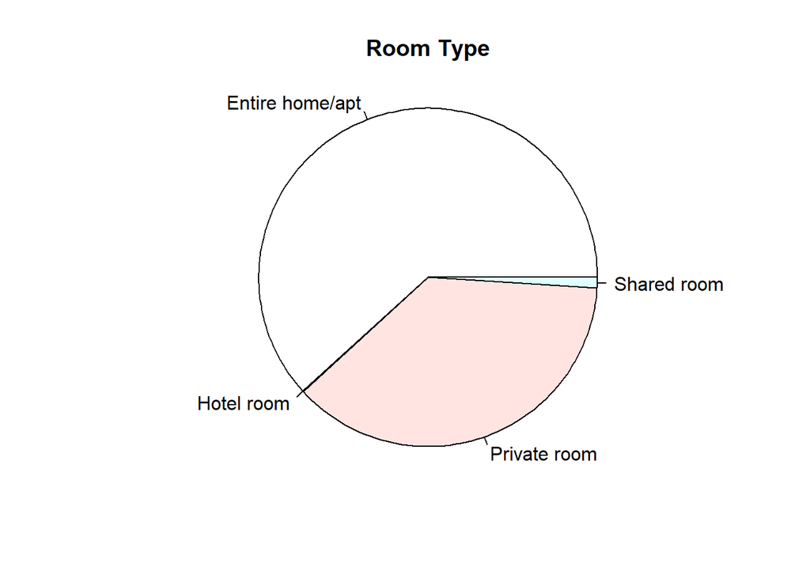

```r
pie(table(L_data_clean$room_type), radius=1, main = "Room Type")
```

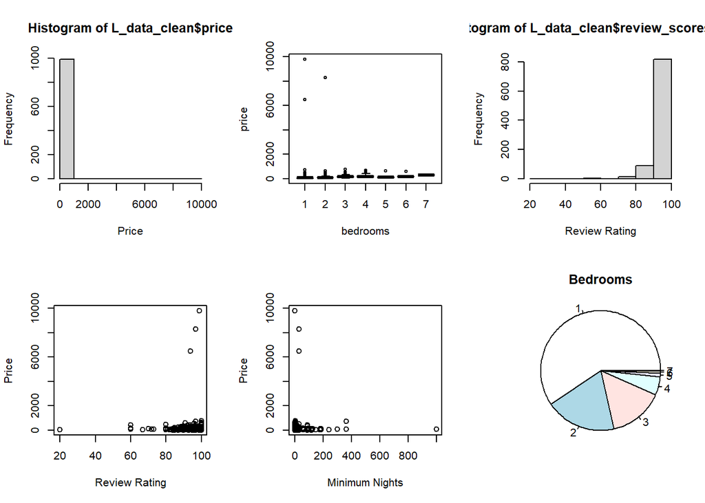

```r
par(mfrow=c(2,3))

hist(L_data_clean$price, xlab = "Price")
boxplot(price~bedrooms, data=L_data_clean)
hist(L_data_clean$review_scores_rating, xlab = "Review Rating")
plot(L_data_clean$review_scores_rating, L_data_clean$price, xlab = "Review Rating", ylab = "Price")
plot(L_data_clean$minimum_nights, L_data_clean$price, xlab = "Minimum Nights", ylab = "Price")
pie(table(L_data_clean$bedrooms), radius=1, main = "Bedrooms")
```

All t/f binary values were converted to dummy variables {$0,1$}. Some numerical values were a character data type - these were converted to numeric (percentages, dollars). Some values were an “N/A” character - these were converted to NA. All missing values were also converted to NA. All NA values in numeric columns were then converted to the mean for the column (below).Several columns were dropped: ‘bathrooms’ and ‘neighbourhood_group_cleansed’ columns due to 100% NA, host_neighbourhood’ due to >85% missing values, and ‘host_total_listings_count’ because it was redunant (column ‘host_listing_counts’ had same values). All unique values for categorical variables were checked for entry errors. I decided against one-hot-encoding for low-cardinality variables for now.

**(2) You should have found some suspicious datapoints in the first part of this question. Create two copies of the dataset: one with the suspicious points removed, the other with them retained. Try training both LASSO and standard regression models on the training dataset using the numerical covariates, optimizing the parameters using crossvalidation with the optimization dataset. In the end you should have four models: standard and LASSO regression, with and without suspicious points. Test their accuracy on the test dataset.**

I will first start by removing only the extreme price points and minimum night points.

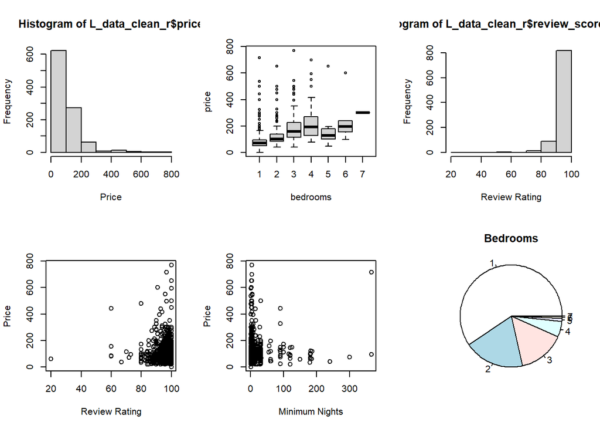

```r
# create separate data set with bad points removed
L_data_clean_r <- L_data_clean

L_data_clean_r$price <- ifelse(L_data_clean_r$price > 1000, NA, L_data_clean_r$price)
L_data_clean_r$minimum_nights <- ifelse(L_data_clean_r$minimum_nights > 400, mean(L_data_clean_r$minimum_nights), L_data_clean_r$minimum_nights)

# view tables with values removed

par(mfrow=c(2,3))

hist(L_data_clean_r$price, xlab = "Price")
boxplot(price~bedrooms, data=L_data_clean_r)
hist(L_data_clean_r$review_scores_rating, xlab = "Review Rating")
plot(L_data_clean_r$review_scores_rating, L_data_clean_r$price, xlab = "Review Rating", ylab = "Price")
plot(L_data_clean_r$minimum_nights, L_data_clean_r$price, xlab = "Minimum Nights", ylab = "Price")
pie(table(L_data_clean_r$bedrooms), radius=1, main = "Bedrooms")
```

```r
# replace NA values with mean

for(i in 1:ncol(L_data_clean_r)){
  if(class(L_data_clean_r[,i]) != "character"){
    L_data_clean_r[is.na(L_data_clean_r[,i]), i] <- mean(L_data_clean_r[,i], na.rm = TRUE)
  }
}
summarize(L_data_clean_r)
```

```
## [1] "1 NAME:[ description ] TYPE:[ character ] NA:[ 1 ] TEXT NA:[ 0 ] MISSING: [ 0 ]"
## [1] "2 NAME:[ neighborhood_overview ] TYPE:[ character ] NA:[ 243 ] TEXT NA:[ 0 ] MISSING: [ 0 ]"
## [1] "3 NAME:[ host_response_time ] TYPE:[ character ] NA:[ 406 ] TEXT NA:[ 0 ] MISSING: [ 0 ]"
## [1] "4 NAME:[ host_response_rate ] TYPE:[ numeric ] NA:[ 0 ] TEXT NA:[ 0 ] MISSING: [ 0 ]"
## [1] "5 NAME:[ host_acceptance_rate ] TYPE:[ numeric ] NA:[ 0 ] TEXT NA:[ 0 ] MISSING: [ 0 ]"
## [1] "6 NAME:[ host_is_superhost ] TYPE:[ numeric ] NA:[ 0 ] TEXT NA:[ 0 ] MISSING: [ 0 ]"
## [1] "7 NAME:[ host_listings_count ] TYPE:[ integer ] NA:[ 0 ] TEXT NA:[ 0 ] MISSING: [ 0 ]"
## [1] "8 NAME:[ host_has_profile_pic ] TYPE:[ numeric ] NA:[ 0 ] TEXT NA:[ 0 ] MISSING: [ 0 ]"
## [1] "9 NAME:[ host_identity_verified ] TYPE:[ numeric ] NA:[ 0 ] TEXT NA:[ 0 ] MISSING: [ 0 ]"
## [1] "10 NAME:[ neighbourhood_cleansed ] TYPE:[ character ] NA:[ 0 ] TEXT NA:[ 0 ] MISSING: [ 0 ]"
## [1] "11 NAME:[ latitude ] TYPE:[ numeric ] NA:[ 0 ] TEXT NA:[ 0 ] MISSING: [ 0 ]"
## [1] "12 NAME:[ longitude ] TYPE:[ numeric ] NA:[ 0 ] TEXT NA:[ 0 ] MISSING: [ 0 ]"
## [1] "13 NAME:[ property_type ] TYPE:[ character ] NA:[ 0 ] TEXT NA:[ 0 ] MISSING: [ 0 ]"
## [1] "14 NAME:[ room_type ] TYPE:[ character ] NA:[ 0 ] TEXT NA:[ 0 ] MISSING: [ 0 ]"
## [1] "15 NAME:[ accommodates ] TYPE:[ integer ] NA:[ 0 ] TEXT NA:[ 0 ] MISSING: [ 0 ]"
```

[output cut: 24 more lines]

```r
for(i in 1:ncol(L_data_clean)){
  if(class(L_data_clean[,i]) != "character"){
    L_data_clean[is.na(L_data_clean[,i]), i] <- mean(L_data_clean[,i], na.rm = TRUE)
  }
}
#summarize(L_data_clean)

for(i in 1:ncol(L_data_clean_test)){
  if(class(L_data_clean_test[,i]) != "character"){
    L_data_clean_test[is.na(L_data_clean_test[,i]), i] <- mean(L_data_clean_test[,i], na.rm = TRUE)
  }
}
#summarize(L_data_clean_test)

for(i in 1:ncol(L_data_clean_opt)){
  if(class(L_data_clean_opt[,i]) != "character"){
    L_data_clean_opt[is.na(L_data_clean_opt[,i]), i] <- mean(L_data_clean_opt[,i], na.rm = TRUE)
  }
}
#summarize(L_data_clean_opt)
```

```r
L_data_clean_r_all <- L_data_clean_r
L_data_clean_test_all <- L_data_clean_test
L_data_clean_opt_all <- L_data_clean_opt

# remove non-numeric columns

L_data_clean = subset(L_data_clean, select = -c(description, neighborhood_overview, host_response_time, neighbourhood_cleansed, property_type, room_type, amenities, first_review, last_review) )

L_data_clean_r = subset(L_data_clean_r, select = -c(description, neighborhood_overview, host_response_time, neighbourhood_cleansed, property_type, room_type, amenities, first_review, last_review) )

L_data_clean_test = subset(L_data_clean_test, select = -c(description, neighborhood_overview, host_response_time, neighbourhood_cleansed, property_type, room_type, amenities, first_review, last_review) )

L_data_clean_opt = subset(L_data_clean_opt, select = -c(description, neighborhood_overview, host_response_time, neighbourhood_cleansed, property_type, room_type, amenities, first_review, last_review) )
```

**Train using LASSO and CV on L_data_clean (dataset without points removed.)**

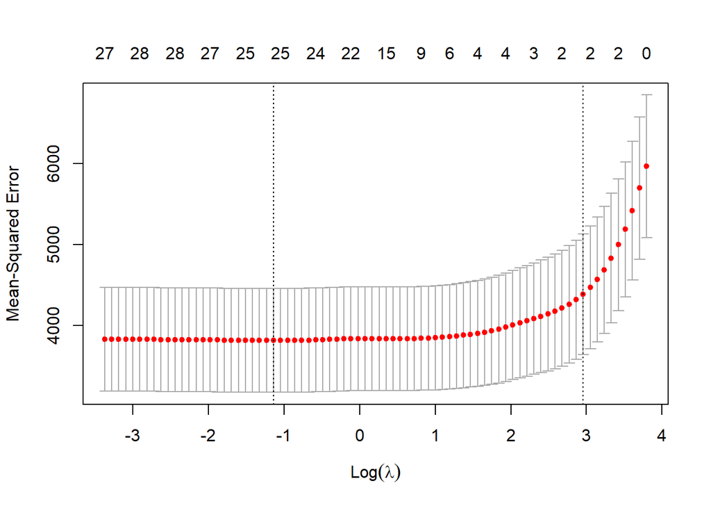

```r
x = model.matrix(price~.,data=L_data_clean)
y = L_data_clean$price


x_opt = model.matrix(price~.,data=L_data_clean_opt)
y_opt = L_data_clean_opt$price

fit_lasso = glmnet(x, y, alpha = 1)

cv_lasso = cv.glmnet(x_opt, y_opt, alpha = 1)

plot(cv_lasso)
```

```r
coef(cv_lasso, s = "lambda.min")
```

```
## 31 x 1 sparse Matrix of class "dgCMatrix"
##                                                          1
## (Intercept)                                  -7.817991e+02
## (Intercept)                                   .
## host_response_rate                           -4.652105e+02
## host_acceptance_rate                          1.794772e+01
## host_is_superhost                            -2.910913e+00
## host_listings_count                          -1.855081e-01
## host_has_profile_pic                          7.281409e+00
## host_identity_verified                       -6.047905e+00
## latitude                                     -1.598229e+01
## longitude                                    -2.035931e+01
## accommodates                                  6.872862e+00
## bedrooms                                      2.867073e+01
## beds                                          .
## minimum_nights                               -1.882878e-02
## maximum_nights                               -4.057456e-03
## has_availability                              4.136888e-01
## number_of_reviews                            -3.962311e-01
## number_of_reviews_ltm                        -3.450363e-01
## number_of_reviews_l30d                       -8.303352e-01
## review_scores_rating                          6.622188e-01
## review_scores_accuracy                        .
## review_scores_cleanliness                     3.645028e+00
## review_scores_checkin                        -3.128900e+00
## review_scores_communication                   .
## review_scores_location                        1.418827e+00
## review_scores_value                          -8.362323e+00
## instant_bookable                             -3.481838e+00
## calculated_host_listings_count                .
## calculated_host_listings_count_entire_homes   9.923618e-01
## calculated_host_listings_count_private_rooms -4.939929e+00
## reviews_per_month                             6.080392e+00
```

```r
min <- cv_lasso$lambda.min

lasso_predictions <- predict(fit_lasso, newx = model.matrix(price~.,data=L_data_clean_test), s = min)

RMSE(lasso_predictions, L_data_clean_test$price)
```

```
## [1] 159.943
```

**Train using LASSO and CV on L_data_clean_r (dataset with points removed.)**

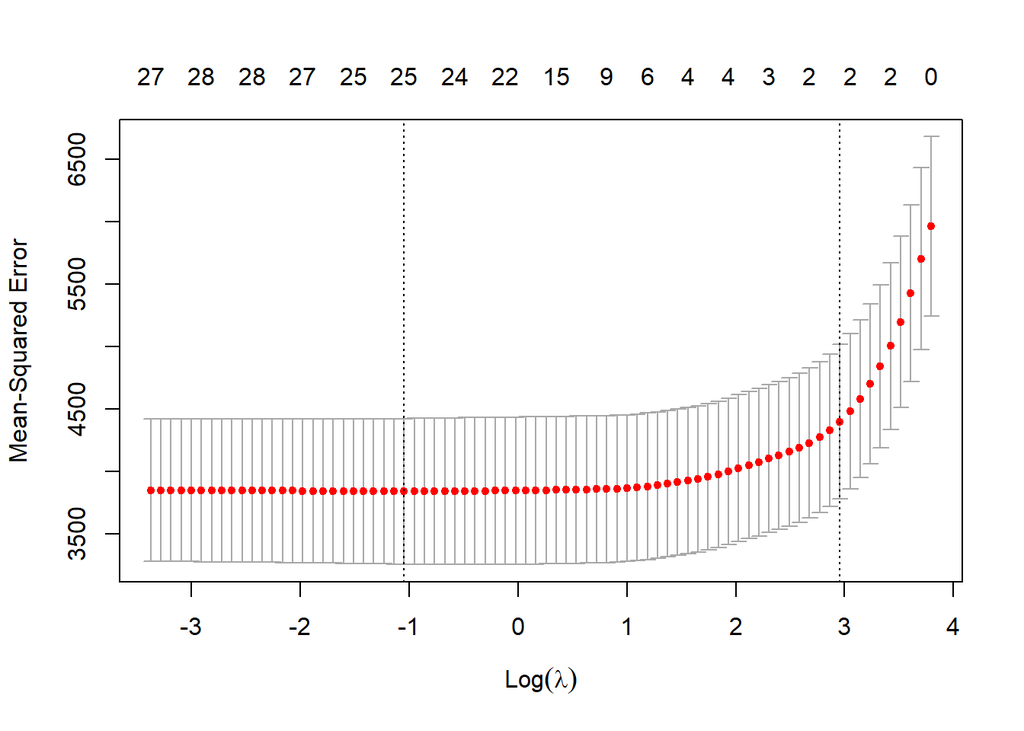

```r
x_r = model.matrix(price~.,data=L_data_clean_r)
y_r = L_data_clean_r$price


x_opt_r = model.matrix(price~.,data=L_data_clean_opt)
y_opt_r = L_data_clean_opt$price

fit_lasso_r = glmnet(x_r, y_r, alpha = 1)

cv_lasso_r = cv.glmnet(x_opt_r, y_opt_r, alpha = 1)

plot(cv_lasso_r)
```

```r
coef(cv_lasso_r, s = "lambda.min")
```

```
## 31 x 1 sparse Matrix of class "dgCMatrix"
##                                                          1
## (Intercept)                                  -8.023748e+02
## (Intercept)                                   .
## host_response_rate                           -4.393555e+02
## host_acceptance_rate                          1.781110e+01
## host_is_superhost                            -2.773427e+00
## host_listings_count                          -1.770022e-01
## host_has_profile_pic                          7.196845e+00
## host_identity_verified                       -5.882282e+00
## latitude                                     -1.515044e+01
## longitude                                    -2.012714e+01
## accommodates                                  6.857766e+00
## bedrooms                                      2.867821e+01
## beds                                          .
## minimum_nights                               -1.812571e-02
## maximum_nights                               -3.972367e-03
## has_availability                              2.311148e-01
## number_of_reviews                            -3.854278e-01
## number_of_reviews_ltm                        -3.300323e-01
## number_of_reviews_l30d                       -8.178165e-01
## review_scores_rating                          6.357011e-01
## review_scores_accuracy                        .
## review_scores_cleanliness                     3.593719e+00
## review_scores_checkin                        -2.933785e+00
## review_scores_communication                   .
## review_scores_location                        1.277548e+00
## review_scores_value                          -8.081016e+00
## instant_bookable                             -3.441226e+00
## calculated_host_listings_count                .
## calculated_host_listings_count_entire_homes   9.671218e-01
## calculated_host_listings_count_private_rooms -4.916587e+00
## reviews_per_month                             5.705662e+00
```

```r
min_r <- cv_lasso_r$lambda.min

lasso_predictions_r <- predict(fit_lasso_r, newx = model.matrix(price~.,data=L_data_clean_test), s = min_r)

RMSE(lasso_predictions_r, L_data_clean_test$price)
```

```
## [1] 64.02231
```

**Train using Linear Regression on L_data_clean (dataset without points removed.)**

```r
fit_lm = lm(price~., data = L_data_clean)

predictions_lm = predict(fit_lm, data = L_data_clean_test)
predictions_lm[1:10]
```

```
##         1         2         3         4         5         6         7         8
## 114.66816 168.26648 265.66081 132.13019 127.36601 214.61458 134.21059  96.78136
##         9        10
## 110.87195  88.29687
```

```r
RMSE(predictions_lm, L_data_clean_test$price)
```

```
## [1] 104.4389
```

```r
summary(fit_lm)
```

```
##
## Call:
## lm(formula = price ~ ., data = L_data_clean)
##
## Residuals:
##    Min     1Q Median     3Q    Max
## -294.9  -74.1  -36.4    9.5 9570.2
##
## Coefficients:
##                                                Estimate Std. Error t value
## (Intercept)                                  -1.150e+04  2.060e+04  -0.559
## host_response_rate                            2.879e+01  9.187e+01   0.313
## host_acceptance_rate                          3.996e+01  6.301e+01   0.634
## host_is_superhost                            -5.842e+01  3.448e+01  -1.694
## host_listings_count                          -4.229e-01  1.314e+00  -0.322
## host_has_profile_pic                         -3.515e+01  2.372e+02  -0.148
## host_identity_verified                       -2.438e+00  3.981e+01  -0.061
## latitude                                      1.707e+02  2.869e+02   0.595
## longitude                                    -4.768e+01  1.552e+02  -0.307
## accommodates                                  6.335e+00  1.326e+01   0.478
## bedrooms                                      3.639e+01  2.851e+01   1.276
## beds                                         -1.363e+01  2.022e+01  -0.674
## minimum_nights                                2.369e-01  3.333e-01   0.711
## maximum_nights                               -7.798e-08  2.182e-07  -0.357
## has_availability                              5.526e+01  9.799e+01   0.564
## number_of_reviews                            -1.968e-01  4.637e-01  -0.424
## number_of_reviews_ltm                         3.550e+00  2.103e+00   1.688
## number_of_reviews_l30d                       -3.654e+00  2.760e+01  -0.132
## review_scores_rating                         -8.887e-01  5.393e+00  -0.165
## review_scores_accuracy                        6.449e+00  3.663e+01   0.176
## review_scores_cleanliness                     2.799e+01  3.320e+01   0.843
## review_scores_checkin                         5.768e+00  4.919e+01   0.117
## review_scores_communication                   1.472e+01  5.409e+01   0.272
## review_scores_location                        9.526e+00  2.888e+01   0.330
## review_scores_value                          -3.285e+01  3.315e+01  -0.991
## instant_bookable                             -8.422e+00  3.776e+01  -0.223
## calculated_host_listings_count               -6.518e+01  9.608e+01  -0.678
## calculated_host_listings_count_entire_homes   6.647e+01  9.606e+01   0.692
## calculated_host_listings_count_private_rooms  6.192e+01  9.679e+01   0.640
## reviews_per_month                            -1.565e+01  2.682e+01  -0.584
```

[output cut: 22 more lines]

```
## review_scores_checkin                          0.9067
## review_scores_communication                    0.7855
## review_scores_location                         0.7416
## review_scores_value                            0.3219
## instant_bookable                               0.8235
## calculated_host_listings_count                 0.4977
## calculated_host_listings_count_entire_homes    0.4891
## calculated_host_listings_count_private_rooms   0.5225
## reviews_per_month                              0.5595
## ---
## Signif. codes:  0 '***' 0.001 '**' 0.01 '*' 0.05 '.' 0.1 ' ' 1
##
## Residual standard error: 460.3 on 970 degrees of freedom
## Multiple R-squared:  0.0197, Adjusted R-squared:  -0.009605
## F-statistic: 0.6723 on 29 and 970 DF,  p-value: 0.9058
```